# Case Study 3: Galeries Lafayette

UNIGE - GSEM - Advanced Data-Driven Decision Making

2023-05-07

Abstract

> *This analysis was prepared by Francisco Arrieta and Jonathan Edwards.*

# General Setup

```r
# options(scipen=999) #prevent scientific notation
# options(scipen=-999) #encourage scientific notation
options(scipen=0) #encourage scientific notation neutral?
```

## Libraries

```r
# modelling
library(psych) #factor analysis tools (PAF PAF)
library(lavaan) #causal analysis
library(lm.beta) # add standarized regression coeffs

# stats
library(nortest) #Kolmogorov-Smirnov-Test
library(corrplot) #correlation matrix plot
library(olsrr)  #VIF and Tolerance Values
library(pastecs) # provides function stat.desc
library(REdaS) #Bartelett's Test

# plotting & formatting
library(ggplot2) #better graphs
library(patchwork) # provides wrap_plots for multiplotting
# library(gridExtra) #provides multiplotting functionality
# library(ggpubr) #provides ggarrange for multiplotting (patchwork better though)
library(semPlot) #for visualization of path diagrams (SEM)
library(lavaanPlot) #for visualization of path diagrams (SEM)
# library(rcompanion)   #Histogram and Normal Curve
library(kableExtra) #makes nice tables

# generic
library(dplyr) #useful data manip functions like arrange, distinct, rename etc included in fpp3
library(stringr) # provides string manip functions like str_split_fixed
library(Hmisc) #describe function that describes features of dataframes
library(data.table) # creating and manipulating datatables
library(knitr) #rmarkdown tools not sure why useful
library(parameters) #get model outputs in table form (good for making tabs)
```

# Formatting

## Tables

The following function was developed by the modelers to facilitate display of results.

```r
# kable table layout options
# do not display NAs and only 2 digits
opts <- options(knitr.kable.NA = '') #knitr.table.format = "latex"

# define table styling options
stable <- function(data, digits = 2, caption="") {
  knitr::kable(data, digits=digits, caption=caption) |>
    # kable_styling(c("striped", "condensed"))
    kable_paper(full_width = T)
}
```

# Functions in alphabetical order

The following functions were developed by the analysts to facilitate calculation and iteration of procedures.

## f_AVE

```r
f_AVE <- function(lambda, theta){

  results <- data.frame()

  # create lambda matrix with ones instead of std.all
  ones <- lambda
  ones[ones>0] <- 1

  # a matrix with dimensions of lambda matrix but with lambdas replaced by thetas
  theta_lb <- theta %*% ones

  # calculate Average Variance Extracted (should be above .5)
  AVE <- (t(lambda) %*% lambda) / (t(lambda) %*% lambda + t(theta_lb) %*% ones )

  # replace all values satisfying condition with NaN for visibility
  AVE_fail <- AVE
  AVE_fail[AVE_fail>.5] <- NaN

  # test result

  if (length(AVE_fail[!is.na(AVE_fail)])>0){
      results["Average Variance Extracted","Result"] <- "Fail"
    } else {
      results["Average Variance Extracted","Result"] <- "Pass"
    }

    kbl <- results |>
      stable() |>
      row_spec(which(results[,"Result"]=="Pass"), bold = T, color = "white", background = "#78BE20") |>
      row_spec(which(results[,"Result"]=="Fail"), bold = T, color = "white", background = "red")

  return(list(kbl,AVE,AVE_fail))
}
```

## f_bartlett

```r
f_bartlett <- function(data){

  brt <- bart_spher(data)

  test_selection = c("p.value","X2")
  results <- data.frame(Value=as.numeric(brt[test_selection]))
  rownames(results) <- c("pvalue", "chisq")

    # bartlett's test (p-value < 0.5)
  if (results["pvalue","Value"] < 0.05){
      results["pvalue","Result"] <- "PASS"
    } else {
      results["pvalue","Result"] <- "FAIL"
    }

  kbl <- results |>
    stable(3) |>
    row_spec(which(results[,"Result"]=="PASS"), bold = T, color = "white", background = "#78BE20") |>
    row_spec(which(results[,"Result"]=="FAIL"), bold = T, color = "white", background = "red")

  return(list(kbl, brt))

}
```

## f_communality

```r
# communalities (exclude variables if < 0.3)
f_communality <- function(fit){

    communality <- data.table("Item"=names(fit$communality),
                             "Communality"=as.numeric(fit$communality))

    # Sort table
    communality <- communality |>
      setorder(cols = "Communality")

    # Display table
    kbl <- communality |>
              stable(caption=paste0("Communality for function \"",fit$fn  ,"\" with rotation \"", fit$rotation, "\" and ", fit$factors, " factors")) |>
              row_spec(which(communality[,1]<.3), bold = T, color = "white", background = "red")

    kbl
}
```

## f_communality_load

```r
# test to see if function calculates communality from loadings
f_communality_load <- function(fit){

  communality_calc <- numeric()
  for (i in 1:nrow(fit$loadings)){

    # test communality calculation
    variableloading = fit$loadings[i,] # loadings 1st variable
    communality_calc[i] = sum(variableloading^2)
    names(communality_calc)[i] <- names(fit$loadings[,1])[i]
    # print(paste0("Communality for ", names(fit$loadings[,1])[i]," = ", communality_calc[i]))

  }

    communality <- data.table("Item"=names(communality_calc),
                             "Communality"=as.numeric(communality_calc))

    # Sort table
    communality <- communality |>
      setorder(cols = "Communality")

    # Display table
    kbl <- communality |>
              stable(caption=paste0("Test - Communality calculated from loadings for function \"",fit$fn  ,"\" with rotation \"", fit$rotation, "\" and ", fit$factors, " factors")) |>
              row_spec(which(communality[,1]<.3), bold = T, color = "white", background = "red")

    kbl
}
```

## f_construct_corr

```r
f_construct_corr <- function(psi){

  results <- data.frame()

  # correlations between constructs (factors...) should be lower than .7
  # replace all values satisfying condition with Fail" for visibility
  psi_fail <- psi
  psi_fail[psi_fail<.7] <- NaN

  # replace diagonal of psi matrix with NA
  diag(psi_fail) <- NaN

  # test result

  if (length(psi_fail[!is.na(psi_fail)])>0){
      results["Construct Correlations","Result"] <- "Fail"
    } else {
      results["Construct Correlations","Result"] <- "Pass"
    }

    kbl <- results |>
      stable() |>
      row_spec(which(results[,"Result"]=="Pass"), bold = T, color = "white", background = "#78BE20") |>
      row_spec(which(results[,"Result"]=="Fail"), bold = T, color = "white", background = "red")

  return(list(kbl,psi,psi_fail))
}
```

## f_construct_rel

```r
f_construct_rel <- function(lambda, theta){

  results <- data.frame()

  # create lambda matrix with ones instead of std.all
  ones <- lambda
  ones[ones>0] <- 1

  # a matrix with dimensions of lambda matrix but with lambdas replaced by thetas
  theta_lb <- theta %*% ones

  # calculate construct reliability (should be above .6)
  constrrel <- (t(lambda) %*% ones)^2 / ((t(lambda) %*% ones)^2 + t(theta_lb) %*% ones )

  # replace all values satisfying condition with NaN for visibility
  constrrel_fail <- constrrel
  constrrel_fail[constrrel_fail>.6] <- NaN

  # test result

  if (length(constrrel_fail[!is.na(constrrel_fail)])>0){
      results["Construct Reliability","Result"] <- "Fail"
    } else {
      results["Construct Reliability","Result"] <- "Pass"
    }

    kbl <- results |>
      stable() |>
      row_spec(which(results[,"Result"]=="Pass"), bold = T, color = "white", background = "#78BE20") |>
      row_spec(which(results[,"Result"]=="Fail"), bold = T, color = "white", background = "red")

  return(list(kbl,constrrel,constrrel_fail))
}
```

## f_corr_matrix

```r
#plot correlation matrix adjusting parameters to see previously identified groupings
f_corr_matrix <- function(data){
corr_matrix <- cor(data)
corrplot(as.matrix(corr_matrix),
         method = "color", #col = c("white","white","white","white","white", "lightgrey", "darkgrey", "black"),
         order = "hclust", addrect = 10, rect.col="black", # rect.col="red",
         addCoef.col = 'black', number.cex = .5,
         tl.col ="black",
         tl.cex = 0.80,
         )
}
```

## f_eigenvalue_load

```r
f_eigenvalue_load <- function(fit){

  Eigenvalue <- numeric()
  for (i in 1:ncol(fit$loadings)){

    # test eigenvalue calculation
    factorloadings = fit$loadings[,i] # loadings 1st factor (default is nfactors = 1)
    Eigenvalue[i] = sum(factorloadings^2)
    # print(paste0("Eigenvalue factor ",names(fit$loadings[1,])[i] ," = ", Eigenvalue))

  }
Eigenvalue
}
```

## f_factor_interp

```r
f_factor_interp <- function(fit, labels, f_interp_list){

 # create a dataframe which lists the variables in one column and in the other the factor on which they load most (the max)
Im_factor <- data.frame(
  Variable = rownames(fit$loadings),
  Loads_on = colnames(fit$loadings)[max.col(fit$loadings)]
  )

# merge the labels data and the factor loaded on data
factor_interp <- merge(labels, Im_factor, by = 'Variable', all.x=T, all.y=F)

# select only the images (all variables containing "Im")
factor_interp <- factor_interp[grep("Im",factor_interp$Variable),]

# order by factor
setorder(factor_interp, Loads_on)

# add a column with the interpretations

factor_interp["Interpretation"] <- "excluded"

for (k in seq_along(f_interp_list)){

  factor_interp["Interpretation"][factor_interp["Loads_on"]==names(f_interp_list[k])] <- f_interp_list[k]

}

kbl <- data.table(factor_interp[c("Variable", "Label_short", "Loads_on","Interpretation")]) |>
  stable()

kbl
}
```

## f_fornell_larcker

```r
f_fornell_larcker <- function(psi, AVE){

  results <- data.frame()

  #psi matrix squared
  psi2 <- psi^2

  # replace diagonal of psi matrix with AVE values
  diag(psi2) <- diag(AVE)

  # create matrix with columns filled with AVE
  AVE_full <- AVE
  AVE_full[is.na(AVE_full)] <- 0 #replace NAs with 0s
  AVE_full <- AVE_full^0 %*% AVE_full # multiply a matrix full of ones with AVE_full to get columns filled with AVE

  # AVE should be higher than squared correlations between constructs
  # substract matrices any psi bigger than AVE will be negative
  AVEpsi_fail <- AVE_full - psi2
  # AVE_full - psi2
  AVEpsi_fail[AVEpsi_fail >= 0] <- NaN

  # test result

  if (length(AVEpsi_fail[!is.na(AVEpsi_fail)])>0){
      results["Fornell-Larcker Criteria","Result"] <- "Fail"
    } else {
      results["Fornell-Larcker Criteria","Result"] <- "Pass"
    }

    kbl <- results |>
      stable() |>
      row_spec(which(results[,"Result"]=="Pass"), bold = T, color = "white", background = "#78BE20") |>
      row_spec(which(results[,"Result"]=="Fail"), bold = T, color = "white", background = "red")

  return(list(kbl,psi2,AVEpsi_fail))
}
```

## f_global_fit_measures

```r
f_global_fit_measures <- function(fit){

  sum <- summary(fit, fit.measures=TRUE, standardized=TRUE)

  test_selection = c("pvalue","chisq","cfi", "rmsea")
  results <- data.frame(Value=sum$fit[test_selection])

  #chi squared pvalue
  if (results["pvalue","Value"] > 0.05){
      results["pvalue","Result"] <- "PASS"
      results["pvalue","Result_bool"] <- 2
    } else {
      results["pvalue","Result"] <- "FAIL"
      results["pvalue","Result_bool"] <- 0
    }

  #chi squared
  results["chisq","Result"] <- "-"

  #CFI
  if (results["cfi","Value"] < 0.9){
      results["cfi","Result"] <- "Definitely reject the model"
      results["cfi","Result_bool"] <- 0
    } else if (results["cfi","Value"]>0.95) {
      results["cfi","Result"] <- "Accept model"
      results["cfi","Result_bool"] <- 2
    } else {
      results["cfi","Result"] <- "High under-rejection rate"
      results["cfi","Result_bool"] <- 1
    }

  #RMSEA
  if (results["rmsea","Value"] <= 0.05){
      results["rmsea","Result"] <- "Good fit"
      results["rmsea","Result_bool"] <- 2
    } else if (results["rmsea","Value"] <= 0.08 | results["rmsea","Value"] > 0.05) {
      results["rmsea","Result"] <- "Acceptable fit"
      results["rmsea","Result_bool"] <- 1
    } else if (results["rmsea","Value"] <= 0.1 | results["rmsea","Value"] > 0.08) {
      results["rmsea","Result"] <- "Bad fit"
      results["rmsea","Result_bool"] <- 0
    } else {
      results["rmsea","Result"] <- "Unacceptable fit"
      results["rmsea","Result_bool"] <- 0
    }

  kbl <- results |>
    stable(3) |>
    row_spec(which(results[,"Result_bool"]==2), bold = T, color = "white", background = "#78BE20") |>
    row_spec(which(results[,"Result_bool"]==1), bold = T, color = "white", background = "orange") |>
    row_spec(which(results[,"Result_bool"]==0), bold = T, color = "white", background = "red")

  return(list(remove_column(kbl, 4), sum))
}
```

## f_indic_rel

```r
f_indic_rel <- function(lambda, theta){

  results <- data.frame()

  # create lambda matrix with ones instead of std.all
  ones <- lambda
  ones[ones>0] <- 1

  # a matrix with dimensions of lambda matrix but with lambdas replaced by thetas
  theta_lb <- theta %*% ones

  # calculate indicator reliabilities (should be larger than 0.4)
  indicrel <- lambda^2/(lambda^2 + theta_lb)
  # indicrel

  # replace all values satisfying condition with NaN for visibility
  indicrel_fail <- indicrel
  indicrel_fail[indicrel_fail>.4] <- NaN

  # test result

  if (length(indicrel_fail[!is.na(indicrel_fail)])>0){
      results["Individual Item Reliability","Result"] <- "Fail"
    } else {
      results["Individual Item Reliability","Result"] <- "Pass"
    }

    kbl <- results |>
      stable() |>
      row_spec(which(results[,"Result"]=="Pass"), bold = T, color = "white", background = "#78BE20") |>
      row_spec(which(results[,"Result"]=="Fail"), bold = T, color = "white", background = "red")

  return(list(kbl,indicrel,indicrel_fail))
}
```

## f_kaiser

```r
f_kaiser <- function(fit){

  #kaiser criterion (retain factors with eigenvalues >1)
  fit_kaiser_nb <- length(which(fit$e.values > 1))
  print(paste0("Kaiser number = ",fit_kaiser_nb))

}
```

## f_KMO

```r
f_KMO <- function(data){

# KMO > 0.6
KMOTEST=KMOS(data_img_EFA)
# print(KMOTEST, sort=T)
KMO <- KMOTEST$KMO

results <- data.frame(Value=KMO)
rownames(results) <- "KMO"

    # KMO > 0.6
  if (results["KMO","Value"] > 0.6){
      results["KMO","Result"] <- "PASS"
    } else {
      results["KMO","Result"] <- "FAIL"
    }

  kbl <- results |>
    stable(3) |>
    row_spec(which(results[,"Result"]=="PASS"), bold = T, color = "white", background = "#78BE20") |>
    row_spec(which(results[,"Result"]=="FAIL"), bold = T, color = "white", background = "red")

  return(kbl)

}
```

## f_loadings

```r
# factor loading functions
f_loadings <- function(fit){

      # print(fit$loadings, cutoff=0.3)
      # print(print_html(model_parameters(fit, loadings=T, threshold = 0.3, summary=T)))

      kbl <- model_parameters(fit, loadings=T, threshold = 0.3, summary=T) |>
        stable()
      kbl
}
```

## f_MSA

```r
f_MSA <- function(data){

  KMOTEST=KMOS(data)
  # Anti-image Correlation (MSA > 0.5)
  MSA_list <- data.table("Item"=names(KMOTEST$MSA), "MSA"=as.numeric(KMOTEST$MSA))

  # Sort table
  MSA_list<- MSA_list |>
    setorder(cols = "MSA")

  # Display table
  kbl_MSA <- MSA_list |>
          stable(3) |>
          row_spec(which(MSA_list[,2]<0.5), bold = T, color = "white", background = "red")

  kbl_MSA

}
```

## f_PAFn

```r
# create multiple paf's with different number of factors
f_PAFn <- function(data, nf=1, rotation){

  # perform multiple PAFs one for each factor number in selection
  PAFn = list()

  i=1
  for (n in nf) {
    PAFn[[i]] <- psych::fa(data, rotate=rotation, scores=TRUE, nfactors = n)
    i=i+1
  }
  names(PAFn) <- nf

  PAFn
}
```

## f_PCAn

```r
# create multiple paf's with different number of factors
f_PCAn <- function(data, nf=1, rotation){

  # perform multiple PAFs one for each factor number in selection
  PCAn = list()

  i=1
  for (n in nf) {
    PCAn[[i]] <- psych::principal(data, rotate=rotation, scores=TRUE, nfactors = n)
    i=i+1
  }
  names(PCAn) <- nf

  PCAn
}
```

## f_scree

```r
f_scree <- function(fit){

  #display Scree-plot (retain factors before elbow)
  plot(fit$e.values,xlab="Factor Number",
       ylab="Eigenvalue",
       main="Scree plot",
       cex.lab=1.2,
       cex.axis=1.2,
       cex.main=1.8,
       col = "#0099F8",
       pch = 19)
  abline(h=1, col = "#7F35B2")

}
```

## f_totalvar_eval

```r
f_totalvar_eval <- function(fit){

  #calculate total variance (does not change if number of factors change)
  fit_EigenValue <- fit$e.values
  fit_Variance <- fit_EigenValue / length(fit$e.values) * 100 # ncol(data) = sum(fit1$e.values) = length(fit1$e.values)
  fit_SumVariance <- cumsum(fit_EigenValue / length(fit$e.values))
  fit_Total_Variance_Explained <- cbind("Factor number"=
                                            seq(1, length.out = length(fit_EigenValue[fit_EigenValue>0])),
                                            EigenValue = fit_EigenValue[fit_EigenValue>0],
                                            Variance = fit_Variance[fit_EigenValue>0],
                                            Total_Variance = fit_SumVariance[fit_EigenValue>0])
  #display table
  kbl <- fit_Total_Variance_Explained |>
    stable(caption=paste0("Total Variance Explained for function \"",fit$fn  ,"\" calculated with \"e.values\" argument for rotation \"", fit$rotation, "\" and ", fit$factors, " factors"))

  kbl

}
```

## f_totalvar_val

```r
f_totalvar_val <- function(fit){

  #calculate total variance (does not change if number of factors change)
  fit_EigenValue <- fit$values
  fit_Variance <- fit_EigenValue / length(fit$values) * 100 # ncol(data) = sum(fit$values) = length(fit$values)
  fit_SumVariance <- cumsum(fit_EigenValue / length(fit$values))
  fit_Total_Variance_Explained <- cbind("Factor number"=
                                            seq(1, length.out = length(fit_EigenValue[fit_EigenValue>0])),
                                            EigenValue = fit_EigenValue[fit_EigenValue>0],
                                            Variance = fit_Variance[fit_EigenValue>0],
                                            Total_Variance = fit_SumVariance[fit_EigenValue>0])
  #display table
  kbl <- fit_Total_Variance_Explained |>
    stable(caption=paste0("Total Variance Explained for function \"",fit$fn  ,"\" calculated with \"values\" argument for rotation \"", fit$rotation, "\" and ", fit$factors, " factors"))

  kbl

}
```

## f_totalvar_load

```r
f_totalvar_load <- function(fit){

  #calculate total variance (does not change if number of factors change)
  fit_EigenValue <- f_eigenvalue_load(fit)
  fit_Variance <- fit_EigenValue / length(fit$values) * 100 # ncol(data) = sum(fit$values) = length(fit$values)
  fit_SumVariance <- cumsum(fit_EigenValue / length(fit$values))
  fit_Total_Variance_Explained <- cbind("Factor number"=
                                            seq(1, length.out = length(fit_EigenValue[fit_EigenValue>0])),
                                            EigenValue = fit_EigenValue[fit_EigenValue>0],
                                            Variance = fit_Variance[fit_EigenValue>0],
                                            Total_Variance = fit_SumVariance[fit_EigenValue>0])
  #display table
  kbl <- fit_Total_Variance_Explained |>
    stable(caption=paste0("Test - Total Variance Explained for function \"",fit$fn  ,"\" calculated with loadings for rotation \"", fit$rotation, "\" and ", fit$factors, " factors"))

  kbl
}
```

# Data preparation

## Load data

```r
survey <- read.csv("Case Study III_Structural Equation Modeling.csv")
labels <- read.csv("Variables and Labels_Galeries Lafayette.csv")

dim(survey)
```

```
## [1] 553  45
```

```r
head(labels)
```

```
##   Variable
## 1      Im1
## 2      Im2
## 3      Im3
## 4      Im4
## 5      Im5
## 6      Im6
##                                                                                    Label
## 1                       What do GLB represent from your point of view?  Large Assortment
## 2                     What do GLB represent from your point of view?  Assortment Variety
## 3      What do GLB represent from your point of view?  Artistic Decoration of Sales Area
## 4      What do GLB represent from your point of view?  Creative Decoration of Sales Area
## 5  What do GLB represent from your point of view?  Appealing Arrangement of Shop Windows
## 6                                 What do GLB represent from your point of view?  France
```

The data consists of 553 records. There are 45 variables corresponding to the answers provided by the responding customers.

## Clean and handle missing data

Next, variables are removed from the data set as they will not be considered for the analysis. Items with value of `999` are transformed as `NA` to equate to the proper data type.

```r
# delete variables unused in analysis (see case study instructions):
survey <- survey |> select(-c("SAT_P1", "SAT_P2", "SAT_P3", "SAT_P4", "SAT_P5", "SAT_P6", "TRU_1", "TRU_2", "TRU_3"))

# replace missing data (999) with NA
survey <- data.frame(sapply(survey,function(x) ifelse((x==999),NA,as.numeric(x))))
```

# Data exploration

## Qurstion labels

To have a better understanding of the type of questions asked, the labels for each question is imported and displayed.

```r
#Make labels more readable
#create copy of label column without variable code
labels["Category"] <- sub("[^-]*\\s-","",labels[["Label"]])

#split this new column (category) into category and short label
labels[c("Category","Label_short")] <- str_split_fixed(labels[["Category"]],"\\?\\s\\s|\\s-", n=2)
# labels[20:25,c("Category","Label_short")]

# print out the table
labels[,c("Variable","Category","Label_short")] |>
  stable()
```

| Variable | Category | Label_short |
| --- | --- | --- |
| Im1 | What do GLB represent from your point of view | Large Assortment |
| Im2 | What do GLB represent from your point of view | Assortment Variety |
| Im3 | What do GLB represent from your point of view | Artistic Decoration of Sales Area |
| Im4 | What do GLB represent from your point of view | Creative Decoration of Sales Area |
| Im5 | What do GLB represent from your point of view | Appealing Arrangement of Shop Windows |
| Im6 | What do GLB represent from your point of view | France |
| Im7 | What do GLB represent from your point of view | French Savoir-vivre |
| Im8 | What do GLB represent from your point of view | Expertise in French Traditional Cuisine |
| Im9 | What do GLB represent from your point of view | French Fashion |
| Im10 | What do GLB represent from your point of view | Gourmet Food |
| Im11 | What do GLB represent from your point of view | High-quality Cosmetics |
| Im12 | What do GLB represent from your point of view | Luxury brands |
| Im13 | What do GLB represent from your point of view | Up tp date Designer Brands |
| Im14 | What do GLB represent from your point of view | Gourmet specialities |
| Im15 | What do GLB represent from your point of view | Professional Selection of Brands |
| Im16 | What do GLB represent from your point of view | Professional Appearance Towards Customers |
| Im17 | What do GLB represent from your point of view | Are Trendy |
| Im18 | What do GLB represent from your point of view | Are Hip |
| Im19 | What do GLB represent from your point of view | Professional Organization |
| Im20 | What do GLB represent from your point of view | Relaxing Shopping |
| Im21 | What do GLB represent from your point of view | A Great Place to Stroll |
| Im22 | What do GLB represent from your point of view | Intimate Shop Atmosphere |
| C_CR1 | CO-CREATION | I would like to participate in an expert-workshop to improve the assortment of Galeries Lafayette Berlin. |
| C_CR2 | CO-CREATION | I would be available to take part in another survey at Galeries Lafayette Berlin. |
| C_CR3 | CO-CREATION | I would like to become a member of a customer group whose opinion is obtained for new products and major changes. |
| C_CR4 | CO-CREATION | I would like to participate in planning and designing special events (e.g. fashion show, introduction of new car models) if asked. |
| C_REP1 | REPURCHASE | I will continue to be a loyal customer of Galeries Lafayette Berlin. |
| C_REP2 | REPURCHASE | I intend to shop at Galeries Lafayette Berlin in the future. |
| C_REP3 | REPURCAHSE | I will surely visit Galeries Lafayette Berlin in the future. |
| COM_A1 | AFFECTIVE COMMITMENT | How strongly are you attached to Galeries Lafayette Berlin? |
| COM_A2 | AFFECTIVE COMMITMENT | How strongly are you emotionally connected to Galeries Lafayette Berlin? |
| COM_A3 | AFFECTIVE COMMITMENT | As a customer I feel (close) attached to GL |
| COM_A4 | AFFECTIVE COMMITMENT | feel a strong emotional bond toward GLB |
| SAT_1 | SATISFACTION | I am very satisfied with Galeries Lafayette Berlin. |
| SAT_2 | SATISFACTION | Overall, I am very satisfied with Galeries Lafayette Berlin. |
| SAT_3 | SATISFACTION | How satisfied are you with Galeries Lafayette Berlin? |
| SAT_P1 | SATISFACTION EMPLOYEES | The employees are capable and professional. |
| SAT_P2 | SATISFACTION EMPLOYEES | The employees know best about their products. |
| SAT_P3 | SATISFACTION EMPLOYEES | The employees are well-informed. |
| SAT_P4 | SATISFACTION EMPLOYEES | The employees are always helpful. |
| SAT_P5 | SATISFACTION EMPLOYEES | The employees are willing to respond to my questions in detail. |
| SAT_P6 | SATISFACTION EMPLOYEES | The employees are friendly. |
| TRU_1 | TRUST | I have the feeling that I can completely rely on GL. |
| TRU_2 | TRUST | GLB will always be honest and trustful with me. |
| TRU_3 | TRUST | GL will treat me always fair as a customer |

## Survey

```r
summary(survey)
```

```
##       Im1             Im2             Im3             Im4             Im5
##  Min.   :1.000   Min.   :1.000   Min.   :1.000   Min.   :1.000   Min.   :1.00
##  1st Qu.:4.000   1st Qu.:4.000   1st Qu.:4.000   1st Qu.:4.000   1st Qu.:4.00
##  Median :5.000   Median :5.000   Median :5.000   Median :5.000   Median :5.00
##  Mean   :4.792   Mean   :4.854   Mean   :4.985   Mean   :5.002   Mean   :5.04
##  3rd Qu.:6.000   3rd Qu.:6.000   3rd Qu.:6.000   3rd Qu.:6.000   3rd Qu.:6.00
##  Max.   :7.000   Max.   :7.000   Max.   :7.000   Max.   :7.000   Max.   :7.00
##  NA's   :14      NA's   :18      NA's   :20      NA's   :10      NA's   :29
##       Im6             Im7            Im8             Im9             Im10
##  Min.   :1.000   Min.   :2.00   Min.   :1.000   Min.   :1.000   Min.   :2.000
##  1st Qu.:5.000   1st Qu.:5.00   1st Qu.:6.000   1st Qu.:4.000   1st Qu.:6.000
##  Median :6.000   Median :6.00   Median :6.000   Median :5.000   Median :6.000
##  Mean   :5.824   Mean   :5.75   Mean   :5.996   Mean   :5.076   Mean   :6.102
##  3rd Qu.:7.000   3rd Qu.:7.00   3rd Qu.:7.000   3rd Qu.:6.000   3rd Qu.:7.000
##  Max.   :7.000   Max.   :7.00   Max.   :7.000   Max.   :7.000   Max.   :7.000
##  NA's   :9       NA's   :26     NA's   :6       NA's   :16      NA's   :6
##       Im11            Im12            Im13            Im14
##  Min.   :1.000   Min.   :1.000   Min.   :1.000   Min.   :1.000
##  1st Qu.:5.000   1st Qu.:5.000   1st Qu.:5.000   1st Qu.:6.000
##  Median :6.000   Median :6.000   Median :6.000   Median :6.000
##  Mean   :5.654   Mean   :5.665   Mean   :5.444   Mean   :6.144
##  3rd Qu.:6.000   3rd Qu.:6.000   3rd Qu.:6.000   3rd Qu.:7.000
##  Max.   :7.000   Max.   :7.000   Max.   :7.000   Max.   :7.000
##  NA's   :12      NA's   :21      NA's   :15      NA's   :24
##       Im15            Im16           Im17            Im18            Im19
##  Min.   :1.000   Min.   :1.00   Min.   :1.000   Min.   :1.000   Min.   :1.000
##  1st Qu.:4.000   1st Qu.:4.00   1st Qu.:4.000   1st Qu.:4.000   1st Qu.:4.000
##  Median :5.000   Median :5.00   Median :5.000   Median :5.000   Median :5.000
##  Mean   :5.098   Mean   :5.13   Mean   :5.018   Mean   :4.571   Mean   :5.148
##  3rd Qu.:6.000   3rd Qu.:6.00   3rd Qu.:6.000   3rd Qu.:6.000   3rd Qu.:6.000
##  Max.   :7.000   Max.   :7.00   Max.   :7.000   Max.   :7.000   Max.   :7.000
##  NA's   :12      NA's   :24     NA's   :12      NA's   :28      NA's   :12
##       Im20            Im21            Im22           C_CR1
##  Min.   :1.000   Min.   :1.000   Min.   :1.000   Min.   :1.000
##  1st Qu.:4.000   1st Qu.:4.000   1st Qu.:3.000   1st Qu.:1.000
##  Median :5.000   Median :5.000   Median :4.000   Median :2.000
##  Mean   :4.669   Mean   :5.135   Mean   :4.289   Mean   :2.674
##  3rd Qu.:6.000   3rd Qu.:6.000   3rd Qu.:6.000   3rd Qu.:4.000
##  Max.   :7.000   Max.   :7.000   Max.   :7.000   Max.   :7.000
##  NA's   :9       NA's   :5       NA's   :17      NA's   :20
```

[output cut: 9 more lines]

```
##  Min.   :1.000   Min.   :1.000   Min.   :1.00   Min.   :1.000   Min.   :1.000
##  1st Qu.:4.000   1st Qu.:4.000   1st Qu.:3.00   1st Qu.:2.000   1st Qu.:2.000
##  Median :5.000   Median :4.000   Median :4.00   Median :3.000   Median :3.000
##  Mean   :4.682   Mean   :4.302   Mean   :3.88   Mean   :3.536   Mean   :3.456
##  3rd Qu.:5.000   3rd Qu.:5.000   3rd Qu.:5.00   3rd Qu.:5.000   3rd Qu.:5.000
##  Max.   :5.000   Max.   :7.000   Max.   :7.00   Max.   :7.000   Max.   :7.000
##  NA's   :18      NA's   :14      NA's   :11     NA's   :18      NA's   :9
##      SAT_1           SAT_2           SAT_3
##  Min.   :2.000   Min.   :1.000   Min.   :1.00
##  1st Qu.:5.000   1st Qu.:5.000   1st Qu.:5.00
##  Median :6.000   Median :6.000   Median :6.00
##  Mean   :5.349   Mean   :5.481   Mean   :5.45
##  3rd Qu.:6.000   3rd Qu.:6.000   3rd Qu.:6.00
##  Max.   :7.000   Max.   :7.000   Max.   :7.00
##  NA's   :5       NA's   :10      NA's   :40
```

Looking at the data we see that all survey questions seem to be based on a 7-level Likert scale.

The data does have missing values which we will handle in the following way: - for Exploratory Factor Analysis we will apply listwise deletion - for Confirmatory Factor Analysis and Structural Equation Modelling we will use Maximum Likelihood to handle the missing data.

# Exploratory Factor Analysis

We begin by performing PFA to identify potential factors that might help in determining the main drivers of Customer Satisfaction and Affective Commitment.

## ROUND 1 EFA

### Variable selection

```r
# excluded image variables (in the first round of EFA we don't exclude any image variables...)
exclude=c()

# the full survey data (includes dependent and independent variables) with excluded image variables (in this first round of EFA we don't exclude anything)
survey_excl_img <- survey |> select(-exclude)

# the data we will use for EFA (images)
data_img_EFA <- survey_excl_img[1:(22-length(exclude))]

# list of excluded variables and their meaning
excludedvars <- filter(labels, Variable %in% exclude)[c("Variable","Label_short")]
excludedvars |>
  stable(caption="Indicator variables we chose to exclude:")
```

Indicator variables we chose to exclude:

| Variable | Label_short |
| --- | --- |

#### handle missing data

```r
# delete missing data (delete listwise)
data_img_EFA <- na.omit(data_img_EFA)

dim(survey)
```

```
## [1] 553  36
```

```r
dim(survey_excl_img)
```

```
## [1] 553  36
```

```r
dim(data_img_EFA)
```

```
## [1] 385  22
```

By removing the `NA` values, we end up with 385 records and 22 variables.

### Check adequacy of correlation Matrix

#### correlation matrix

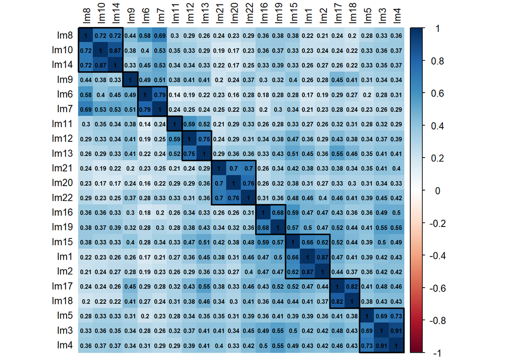

```r
f_corr_matrix(data_img_EFA)
```

Variables to look out for going forward:

- Correlations for Images 9 and 11 are fairly evenly distributed across all other variables, they do not correlate with a specific group of other variables.
- Pairs of images: (17,18), are highly correlated and similar correlation profiles, their correlations to other variables are similar. Same comment to a lesser degree for pairs (6,7) and (16,19). Each of these variable pairs will most likely make up a factor.

#### Bartlett test

```r
# p-value < 0.5
# pass/ fail
f_bartlett(data_img_EFA)[[1]]
```

|  | Value | Result |
| --- | --- | --- |
| pvalue | 0.000 | PASS |
| chisq | 6451.238 |  |

```r
# details
f_bartlett(data_img_EFA)[[2]]
```

```
##  Bartlett's Test of Sphericity
##
## Call: bart_spher(x = data)
##
##      X2 = 6451.238
##      df = 231
## p-value < 2.22e-16
```

The Bartlett Test tests the hypothesis that the sample originates from a population, where all variables are uncorrelated. The null hypothesis of Bartlett’s test rejected meaning that the data is not uncorrelated and indicates it is fit for factor analysis.

#### KMO test

```r
# KMO > 0.6
f_KMO(data_img_EFA)
```

|  | Value | Result |
| --- | --- | --- |
| KMO | 0.877 | PASS |

The KMO is above 0.6 which indicates the data is well suited for factor analysis.

#### Anti-image Correlation (MSA)

```r
# MSA > 0.5
f_MSA(data_img_EFA)
```

| Item | MSA |
| --- | --- |
| Im2 | 0.822 |
| Im6 | 0.822 |
| Im1 | 0.824 |
| Im20 | 0.827 |
| Im14 | 0.827 |
| Im10 | 0.829 |
| Im7 | 0.845 |
| Im4 | 0.854 |
| Im18 | 0.855 |
| Im3 | 0.864 |
| Im17 | 0.864 |
| Im13 | 0.872 |
| Im12 | 0.879 |
| Im22 | 0.879 |
| Im16 | 0.909 |
| Im11 | 0.911 |
| Im21 | 0.915 |
| Im8 | 0.930 |
| Im9 | 0.938 |
| Im19 | 0.940 |
| Im5 | 0.955 |
| Im15 | 0.965 |

Variables with MSA values above 0.5 are suited for factor analysis.

Presence of items with low MSA’s (<0.5) could indicate that an important topic has not been well covered in the questionnaire.

In our case, all variables have MSA above 0.5.

### Determine number of factors

```r
# factor analysis
PAF1 <- psych::fa(data_img_EFA, rotate="varimax", scores=TRUE)
# note: by default number of factors = 1 if it is not specified
```

#### Scree

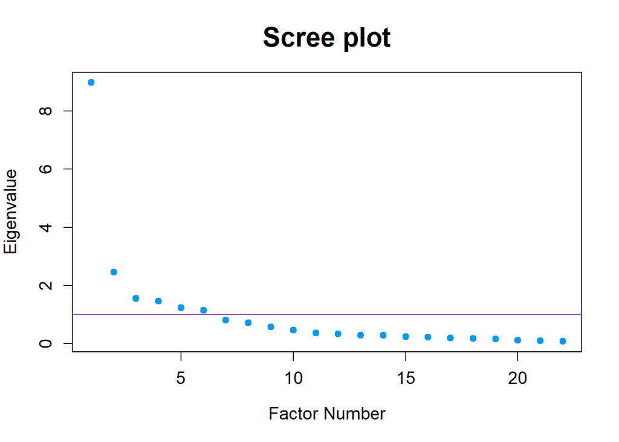

```r
f_scree(PAF1)
```

The scree plot suggests we should keep the factors before the “elbow”. In our case this might be 2, 6 and potentially 8 but this is hard to tell.

#### Kaiser Criterion

```r
f_kaiser(PAF1)
```

```
## [1] "Kaiser number = 6"
```

The Kaiser criterion suggests we should retain factors with eigenvalues bigger than 1.

There are 6 factors satisfying this condition.

It is common practice to keep one more factor than the result of the Kaiser criterion, so 7.

#### Total variance explained

```r
f_totalvar_eval(PAF1)
```

Total Variance Explained for function “fa” calculated with “e.values” argument for rotation “varimax” and 1 factors

| Factor number | EigenValue | Variance | Total_Variance |
| --- | --- | --- | --- |
| 1 | 8.98 | 40.81 | 0.41 |
| 2 | 2.47 | 11.21 | 0.52 |
| 3 | 1.56 | 7.10 | 0.59 |
| 4 | 1.46 | 6.62 | 0.66 |
| 5 | 1.25 | 5.67 | 0.71 |
| 6 | 1.15 | 5.22 | 0.77 |
| 7 | 0.81 | 3.68 | 0.80 |
| 8 | 0.71 | 3.23 | 0.84 |
| 9 | 0.57 | 2.58 | 0.86 |
| 10 | 0.46 | 2.08 | 0.88 |
| 11 | 0.36 | 1.64 | 0.90 |
| 12 | 0.33 | 1.51 | 0.91 |
| 13 | 0.29 | 1.34 | 0.93 |
| 14 | 0.28 | 1.29 | 0.94 |
| 15 | 0.25 | 1.13 | 0.95 |
| 16 | 0.23 | 1.04 | 0.96 |
| 17 | 0.20 | 0.92 | 0.97 |
| 18 | 0.19 | 0.85 | 0.98 |
| 19 | 0.16 | 0.72 | 0.99 |
| 20 | 0.12 | 0.53 | 0.99 |
| 21 | 0.10 | 0.46 | 1.00 |
| 22 | 0.08 | 0.37 | 1.00 |

With 7 factors we would explain 80% of the variance.

We notice that the gain in variance explanation from 7 to 8 factors (3.23%) is comparable to the one from 6 to 7 (3.68%) but after there is a sharp drop, this again could indicate that we might need 8 factors, which would explain 84% of the total variance.

### Factor number selection

Based on the results above we decide to test factor analysis solutions for 6, 7 and 8 factors.

```r
# select nb of factors to explore
nf = c(6,7,8)
```

### n factor PAF

```r
PAFn <- f_PAFn(data_img_EFA, nf, "varimax")
PAFn_obl = f_PAFn(data_img_EFA, nf, "promax")
```

#### Communality

```r
#communalities for all selected number of factors (eliminate variables with communality < 0.3)

for (i in 1:length(nf)) {

    cat("##### Number of factors =", nf[[i]], "{.unnumbered .tabset}" ,"\n")

    print(f_communality(PAFn[[i]]))

    cat("\n\n")
}
```

##### Number of factors = 6

Communality for function “fa” with rotation “varimax” and 6 factors

| Item | Communality |
| --- | --- |
| Im11 | 0.45 |
| Im9 | 0.46 |
| Im16 | 0.47 |
| Im19 | 0.52 |
| Im5 | 0.55 |
| Im18 | 0.57 |
| Im15 | 0.63 |
| Im21 | 0.65 |
| Im17 | 0.70 |
| Im13 | 0.70 |
| Im6 | 0.71 |
| Im12 | 0.73 |
| Im8 | 0.74 |
| Im14 | 0.76 |
| Im2 | 0.76 |
| Im10 | 0.78 |
| Im7 | 0.78 |
| Im20 | 0.79 |
| Im22 | 0.79 |
| Im1 | 0.84 |
| Im3 | 0.85 |
| Im4 | 0.92 |

##### Number of factors = 7

Communality for function “fa” with rotation “varimax” and 7 factors

| Item | Communality |
| --- | --- |
| Im11 | 0.44 |
| Im9 | 0.46 |
| Im16 | 0.47 |
| Im19 | 0.53 |
| Im5 | 0.54 |
| Im15 | 0.63 |
| Im21 | 0.65 |
| Im13 | 0.70 |
| Im18 | 0.71 |
| Im8 | 0.72 |
| Im6 | 0.76 |
| Im2 | 0.78 |
| Im22 | 0.79 |
| Im20 | 0.79 |
| Im14 | 0.81 |
| Im12 | 0.83 |
| Im7 | 0.85 |
| Im1 | 0.86 |
| Im3 | 0.86 |
| Im10 | 0.89 |
| Im17 | 0.95 |
| Im4 | 0.97 |

##### Number of factors = 8

Communality for function “fa” with rotation “varimax” and 8 factors

| Item | Communality |
| --- | --- |
| Im11 | 0.45 |
| Im9 | 0.46 |
| Im5 | 0.58 |
| Im19 | 0.62 |
| Im15 | 0.65 |
| Im21 | 0.65 |
| Im13 | 0.70 |
| Im8 | 0.72 |
| Im18 | 0.74 |
| Im6 | 0.76 |
| Im22 | 0.78 |
| Im16 | 0.80 |
| Im2 | 0.81 |
| Im20 | 0.81 |
| Im12 | 0.84 |
| Im7 | 0.85 |
| Im14 | 0.85 |
| Im3 | 0.86 |
| Im10 | 0.90 |
| Im17 | 0.93 |
| Im1 | 0.94 |
| Im4 | 0.97 |

Typically we should think about excluding variables with communalities below 0.3.

There are no variables satisfying this condition above.

But we still keep an eye out for those variables with the lowest communality: Im9 and Im11.

#### Factor loadings

```r
# loadings for all selected number of factors

for (i in 1:length(nf)) {

    cat("##### Number of factors =", nf[[i]], "{.unnumbered .tabset}" ,"\n")

    cat("###### Structure Matrix {.unnumbered}" ,"\n")

    print(f_loadings(PAFn[[i]]))

    cat("###### Pattern Matrix{.unnumbered}" ,"\n")

    print(f_loadings(PAFn_obl[[i]]))

    cat("\n\n")
}
```

##### Number of factors = 6

###### Structure Matrix

| Variable | MR2 | MR5 | MR1 | MR4 | MR3 | MR6 | Complexity | Uniqueness |
| --- | --- | --- | --- | --- | --- | --- | --- | --- |
| Im1 |  | 0.86 |  |  |  |  | 1.30 | 0.16 |
| Im2 |  | 0.83 |  |  |  |  | 1.24 | 0.24 |
| Im3 |  |  | 0.83 |  |  |  | 1.51 | 0.15 |
| Im4 |  |  | 0.88 |  |  |  | 1.42 | 0.08 |
| Im5 |  |  | 0.64 |  |  |  | 1.74 | 0.45 |
| Im6 | 0.61 |  |  |  |  | 0.56 | 2.12 | 0.29 |
| Im7 | 0.72 |  |  |  |  | 0.48 | 1.88 | 0.22 |
| Im8 | 0.81 |  |  |  |  |  | 1.25 | 0.26 |
| Im9 | 0.35 |  |  | 0.32 |  | 0.43 | 3.51 | 0.54 |
| Im10 | 0.80 |  |  |  |  |  | 1.42 | 0.22 |
| Im11 |  |  |  | 0.59 |  |  | 1.62 | 0.55 |
| Im12 |  |  |  | 0.79 |  |  | 1.34 | 0.27 |
| Im13 |  |  |  | 0.73 |  |  | 1.66 | 0.30 |
| Im14 | 0.80 |  |  |  |  |  | 1.42 | 0.24 |
| Im15 |  | 0.60 |  |  |  |  | 2.76 | 0.37 |
| Im16 |  | 0.48 | 0.37 |  |  |  | 2.78 | 0.53 |
| Im17 |  | 0.35 | 0.31 | 0.39 |  | 0.54 | 3.66 | 0.30 |
| Im18 |  |  |  | 0.35 |  | 0.50 | 3.48 | 0.43 |
| Im19 |  | 0.46 | 0.40 |  |  |  | 3.45 | 0.48 |
| Im20 |  |  |  |  | 0.84 |  | 1.22 | 0.21 |
| Im21 |  |  |  |  | 0.73 |  | 1.43 | 0.35 |
| Im22 |  |  |  |  | 0.79 |  | 1.60 | 0.21 |

###### Pattern Matrix

| Variable | MR2 | MR5 | MR1 | MR4 | MR3 | MR6 | Complexity | Uniqueness |
| --- | --- | --- | --- | --- | --- | --- | --- | --- |
| Im1 |  | 1.05 |  |  |  |  | 1.06 | 0.16 |
| Im2 |  | 1.03 |  |  |  |  | 1.07 | 0.24 |
| Im3 |  |  | 0.99 |  |  |  | 1.03 | 0.15 |
| Im4 |  |  | 1.06 |  |  |  | 1.05 | 0.08 |
| Im5 |  |  | 0.74 |  |  |  | 1.03 | 0.45 |
| Im6 | 0.52 |  |  |  |  | 0.68 | 2.22 | 0.29 |
| Im7 | 0.65 |  |  |  |  | 0.56 | 2.24 | 0.22 |
| Im8 | 0.80 |  |  |  |  |  | 1.05 | 0.26 |
| Im9 |  |  |  |  |  | 0.48 | 1.95 | 0.54 |
| Im10 | 0.81 |  |  |  |  |  | 1.23 | 0.22 |
| Im11 |  |  |  | 0.67 |  |  | 1.15 | 0.55 |
| Im12 |  |  |  | 0.91 |  |  | 1.03 | 0.27 |
| Im13 |  |  |  | 0.79 |  |  | 1.09 | 0.30 |
| Im14 | 0.80 |  |  |  |  |  | 1.18 | 0.24 |
| Im15 |  | 0.60 |  |  |  |  | 1.18 | 0.37 |
| Im16 |  | 0.46 |  |  |  |  | 1.81 | 0.53 |
| Im17 |  |  |  |  |  | 0.57 | 1.97 | 0.30 |
| Im18 |  |  |  |  |  | 0.54 | 1.91 | 0.43 |
| Im19 |  | 0.39 |  |  |  |  | 2.15 | 0.48 |
| Im20 |  |  |  |  | 0.92 |  | 1.07 | 0.21 |
| Im21 |  |  |  |  | 0.76 |  | 1.07 | 0.35 |
| Im22 |  |  |  |  | 0.80 |  | 1.04 | 0.21 |

##### Number of factors = 7

###### Structure Matrix

| Variable | MR5 | MR1 | MR3 | MR2 | MR4 | MR7 | MR6 | Complexity | Uniqueness |
| --- | --- | --- | --- | --- | --- | --- | --- | --- | --- |
| Im1 | 0.86 |  |  |  |  |  |  | 1.33 | 0.14 |
| Im2 | 0.83 |  |  |  |  |  |  | 1.27 | 0.22 |
| Im3 |  | 0.83 |  |  |  |  |  | 1.56 | 0.14 |
| Im4 |  | 0.90 |  |  |  |  |  | 1.40 | 0.03 |
| Im5 |  | 0.63 |  |  |  |  |  | 1.85 | 0.46 |
| Im6 |  |  |  |  |  | 0.83 |  | 1.25 | 0.24 |
| Im7 |  |  |  | 0.32 |  | 0.84 |  | 1.44 | 0.15 |
| Im8 |  |  |  | 0.63 |  | 0.51 |  | 2.31 | 0.28 |
| Im9 |  |  |  |  | 0.33 | 0.45 |  | 3.45 | 0.54 |
| Im10 |  |  |  | 0.87 |  |  |  | 1.35 | 0.11 |
| Im11 |  |  |  |  | 0.58 |  |  | 1.72 | 0.56 |
| Im12 |  |  |  |  | 0.85 |  |  | 1.30 | 0.17 |
| Im13 |  |  |  |  | 0.72 |  |  | 1.81 | 0.30 |
| Im14 |  |  |  | 0.81 |  |  |  | 1.50 | 0.19 |
| Im15 | 0.59 |  |  |  |  |  |  | 2.97 | 0.37 |
| Im16 | 0.46 | 0.34 |  |  |  |  |  | 3.44 | 0.53 |
| Im17 |  |  |  |  |  |  | 0.84 | 1.76 | 0.05 |
| Im18 |  |  |  |  |  |  | 0.72 | 1.85 | 0.29 |
| Im19 | 0.43 | 0.37 |  |  |  |  |  | 4.25 | 0.47 |
| Im20 |  |  | 0.85 |  |  |  |  | 1.21 | 0.21 |
| Im21 |  |  | 0.73 |  |  |  |  | 1.44 | 0.35 |
| Im22 |  |  | 0.78 |  |  |  |  | 1.62 | 0.21 |

###### Pattern Matrix

| Variable | MR5 | MR1 | MR2 | MR3 | MR4 | MR7 | MR6 | Complexity | Uniqueness |
| --- | --- | --- | --- | --- | --- | --- | --- | --- | --- |
| Im1 | 1.08 |  |  |  |  |  |  | 1.06 | 0.14 |
| Im2 | 1.05 |  |  |  |  |  |  | 1.06 | 0.22 |
| Im3 |  | 1.00 |  |  |  |  |  | 1.02 | 0.14 |
| Im4 |  | 1.13 |  |  |  |  |  | 1.04 | 0.03 |
| Im5 |  | 0.72 |  |  |  |  |  | 1.02 | 0.46 |
| Im6 |  |  |  |  |  | 0.92 |  | 1.06 | 0.24 |
| Im7 |  |  |  |  |  | 0.89 |  | 1.06 | 0.15 |
| Im8 |  |  | 0.62 |  |  | 0.38 |  | 1.74 | 0.28 |
| Im9 |  |  |  |  |  | 0.42 |  | 2.10 | 0.54 |
| Im10 |  |  | 1.04 |  |  |  |  | 1.03 | 0.11 |
| Im11 |  |  |  |  | 0.65 |  |  | 1.14 | 0.56 |
| Im12 |  |  |  |  | 1.01 |  |  | 1.04 | 0.17 |
| Im13 |  |  |  |  | 0.78 |  |  | 1.08 | 0.30 |
| Im14 |  |  | 0.94 |  |  |  |  | 1.01 | 0.19 |
| Im15 | 0.60 |  |  |  |  |  |  | 1.17 | 0.37 |
| Im16 | 0.40 |  |  |  |  |  |  | 2.69 | 0.53 |
| Im17 |  |  |  |  |  |  | 1.09 | 1.02 | 0.05 |
| Im18 |  |  |  |  |  |  | 0.92 | 1.02 | 0.29 |
| Im19 | 0.33 |  |  |  |  |  |  | 3.23 | 0.47 |
| Im20 |  |  |  | 0.94 |  |  |  | 1.05 | 0.21 |
| Im21 |  |  |  | 0.78 |  |  |  | 1.06 | 0.35 |
| Im22 |  |  |  | 0.81 |  |  |  | 1.05 | 0.21 |

##### Number of factors = 8

###### Structure Matrix

| Variable | MR1 | MR3 | MR4 | MR7 | MR2 | MR5 | MR6 | MR8 | Complexity | Uniqueness |
| --- | --- | --- | --- | --- | --- | --- | --- | --- | --- | --- |
| Im1 |  |  |  |  |  | 0.88 |  |  | 1.45 | 0.06 |
| Im2 |  |  |  |  |  | 0.82 |  |  | 1.45 | 0.19 |
| Im3 | 0.81 |  |  |  |  |  |  |  | 1.66 | 0.14 |
| Im4 | 0.89 |  |  |  |  |  |  |  | 1.47 | 0.03 |
| Im5 | 0.65 |  |  |  |  |  |  |  | 1.84 | 0.42 |
| Im6 |  |  |  | 0.83 |  |  |  |  | 1.23 | 0.24 |
| Im7 |  |  |  | 0.84 | 0.30 |  |  |  | 1.40 | 0.15 |
| Im8 |  |  |  | 0.54 | 0.59 |  |  |  | 2.56 | 0.28 |
| Im9 |  |  | 0.33 | 0.46 |  |  |  |  | 3.34 | 0.54 |
| Im10 |  |  |  |  | 0.87 |  |  |  | 1.41 | 0.10 |
| Im11 |  |  | 0.58 |  |  |  |  |  | 1.72 | 0.55 |
| Im12 |  |  | 0.86 |  |  |  |  |  | 1.28 | 0.16 |
| Im13 |  |  | 0.72 |  |  |  |  |  | 1.78 | 0.30 |
| Im14 |  |  |  |  | 0.83 |  |  |  | 1.49 | 0.15 |
| Im15 |  |  |  |  |  | 0.47 |  | 0.39 | 4.81 | 0.35 |
| Im16 |  |  |  |  |  |  |  | 0.77 | 1.78 | 0.20 |
| Im17 |  |  |  |  |  |  | 0.82 |  | 1.82 | 0.07 |
| Im18 |  |  |  |  |  |  | 0.74 |  | 1.76 | 0.26 |
| Im19 | 0.30 |  |  |  |  |  |  | 0.54 | 3.68 | 0.38 |
| Im20 |  | 0.86 |  |  |  |  |  |  | 1.20 | 0.19 |
| Im21 |  | 0.73 |  |  |  |  |  |  | 1.44 | 0.35 |
| Im22 |  | 0.78 |  |  |  |  |  |  | 1.63 | 0.22 |

###### Pattern Matrix

| Variable | MR1 | MR3 | MR7 | MR2 | MR4 | MR5 | MR6 | MR8 | Complexity | Uniqueness |
| --- | --- | --- | --- | --- | --- | --- | --- | --- | --- | --- |
| Im1 |  |  |  |  |  | 1.04 |  |  | 1.01 | 0.06 |
| Im2 |  |  |  |  |  | 0.95 |  |  | 1.02 | 0.19 |
| Im3 | 0.90 |  |  |  |  |  |  |  | 1.02 | 0.14 |
| Im4 | 1.03 |  |  |  |  |  |  |  | 1.03 | 0.03 |
| Im5 | 0.72 |  |  |  |  |  |  |  | 1.11 | 0.42 |
| Im6 |  |  | 0.98 |  |  |  |  |  | 1.06 | 0.24 |
| Im7 |  |  | 0.95 |  |  |  |  |  | 1.05 | 0.15 |
| Im8 |  |  | 0.43 | 0.49 |  |  |  |  | 2.39 | 0.28 |
| Im9 |  |  | 0.45 |  |  |  |  |  | 1.92 | 0.54 |
| Im10 |  |  |  | 0.97 |  |  |  |  | 1.01 | 0.10 |
| Im11 |  |  |  |  | 0.66 |  |  |  | 1.15 | 0.55 |
| Im12 |  |  |  |  | 1.04 |  |  |  | 1.05 | 0.16 |
| Im13 |  |  |  |  | 0.79 |  |  |  | 1.06 | 0.30 |
| Im14 |  |  |  | 0.92 |  |  |  |  | 1.02 | 0.15 |
| Im15 |  |  |  |  |  | 0.35 |  | 0.36 | 2.73 | 0.35 |
| Im16 |  |  |  |  |  |  |  | 1.02 | 1.03 | 0.20 |
| Im17 |  |  |  |  |  |  | 0.98 |  | 1.01 | 0.07 |
| Im18 |  |  |  |  |  |  | 0.90 |  | 1.01 | 0.26 |
| Im19 |  |  |  |  |  |  |  | 0.63 | 1.11 | 0.38 |
| Im20 |  | 0.98 |  |  |  |  |  |  | 1.09 | 0.19 |
| Im21 |  | 0.79 |  |  |  |  |  |  | 1.06 | 0.35 |
| Im22 |  | 0.82 |  |  |  |  |  |  | 1.06 | 0.22 |

Looking at the **6 factor solution**, we see quite a lot of variables cross-loading on multiple factors: Im6, Im7, Im9, Im16, Im17, Im18, Im19. These are a lot of cross-loading variables, in addition we have already commented above looking at the correlation matrix that pairs of variables (Im16, Im19) and (Im17, Im18) will most likely need their own factor. We need to consider more factors.

The **7 factor solution** seems better. There are less cross-loading elements. We notice though that the pair (Im16, Im19) still doesn’t have its own factor to load on as we might expect.

The **8 factor solution** is in our opinion the best out of the 3. The high correlation pairs now mostly all load on their own factors and we have many less cross-loading elements.

The remaining cross-loading elements are: Im8, Im9 and Im15 and Im19 to a lesser extent.

We now perform a second round of exploratory factor analysis but excluding the 3 variables Im8, Im9, Im15

## ROUND 2 EFA

### Variable selection

```r
# excluded image variables (in the first round of EFA we don't exclude any image variables...)
exclude=c("Im8", "Im9", "Im15")

# the full survey data (includes dependent and independent variables) with excluded image variables (in this first round of EFA we don't exclude anything)
survey_excl_img <- survey |> select(-exclude)

# the data we will use for EFA (images)
data_img_EFA <- survey_excl_img[1:(22-length(exclude))]

# list of excluded variables and their meaning
excludedvars <- filter(labels, Variable %in% exclude)[c("Variable","Label_short")]
excludedvars |>
  stable(caption="Indicator variables we chose to exclude:")
```

Indicator variables we chose to exclude:

| Variable | Label_short |
| --- | --- |
| Im8 | Expertise in French Traditional Cuisine |
| Im9 | French Fashion |
| Im15 | Professional Selection of Brands |

#### handle missing data

```r
# delete missing data (delete listwise)
data_img_EFA <- na.omit(data_img_EFA)

dim(survey)
```

```
## [1] 553  36
```

```r
dim(survey_excl_img)
```

```
## [1] 553  33
```

```r
dim(data_img_EFA)
```

```
## [1] 394  19
```

In this case, we end up with 394 records and 19 variables.

### Factor number selection

In addition to the preferred 8 factor solution we also keep the 7 factor solution just in case.

```r
# select nb of factors to explore
nf = c(7,8)
```

### n factor PAF

```r
PAFn <- f_PAFn(data_img_EFA, nf, "varimax")
PAFn_obl = f_PAFn(data_img_EFA, nf, "promax")
```

#### Communality

```r
#communalities for all selected number of factors (eliminate variables with communality < 0.3)

for (i in 1:length(nf)) {

    cat("##### Number of factors =", nf[[i]], "{.unnumbered .tabset}" ,"\n")

    print(f_communality(PAFn[[i]]))

    cat("\n\n")
}
```

##### Number of factors = 7

Communality for function “fa” with rotation “varimax” and 7 factors

| Item | Communality |
| --- | --- |
| Im16 | 0.43 |
| Im11 | 0.43 |
| Im19 | 0.51 |
| Im5 | 0.55 |
| Im21 | 0.64 |
| Im18 | 0.67 |
| Im13 | 0.69 |
| Im7 | 0.72 |
| Im14 | 0.78 |
| Im22 | 0.78 |
| Im20 | 0.79 |
| Im2 | 0.81 |
| Im3 | 0.86 |
| Im12 | 0.87 |
| Im1 | 0.91 |
| Im6 | 0.93 |
| Im4 | 0.97 |
| Im10 | 0.97 |
| Im17 | 1.00 |

##### Number of factors = 8

Communality for function “fa” with rotation “varimax” and 8 factors

| Item | Communality |
| --- | --- |
| Im11 | 0.43 |
| Im5 | 0.58 |
| Im21 | 0.64 |
| Im16 | 0.67 |
| Im18 | 0.68 |
| Im13 | 0.69 |
| Im7 | 0.69 |
| Im19 | 0.70 |
| Im2 | 0.76 |
| Im14 | 0.78 |
| Im22 | 0.78 |
| Im20 | 0.81 |
| Im3 | 0.86 |
| Im12 | 0.87 |
| Im4 | 0.97 |
| Im6 | 0.99 |
| Im10 | 1.00 |
| Im17 | 1.00 |
| Im1 | 1.00 |

All communalities are above 0.3.

Im11 is amongst the lowest communality variables in both the 7 and 8 factor solutions.

#### Factor loadings

```r
# loadings for all selected number of factors

for (i in 1:length(nf)) {

    cat("##### Number of factors =", nf[[i]], "{.unnumbered .tabset}" ,"\n")

    cat("###### Structure Matrix {.unnumbered}" ,"\n")

    print(f_loadings(PAFn[[i]]))

    cat("###### Pattern Matrix{.unnumbered}" ,"\n")

    print(f_loadings(PAFn_obl[[i]]))

    cat("\n\n")
}
```

##### Number of factors = 7

###### Structure Matrix

| Variable | MR1 | MR3 | MR4 | MR5 | MR2 | MR6 | MR7 | Complexity | Uniqueness |
| --- | --- | --- | --- | --- | --- | --- | --- | --- | --- |
| Im1 |  |  |  | 0.87 |  |  |  | 1.40 | 0.09 |
| Im2 |  |  |  | 0.83 |  |  |  | 1.35 | 0.19 |
| Im3 | 0.84 |  |  |  |  |  |  | 1.46 | 0.14 |
| Im4 | 0.92 |  |  |  |  |  |  | 1.33 | 0.03 |
| Im5 | 0.64 |  |  |  |  |  |  | 1.73 | 0.45 |
| Im6 |  |  |  |  |  |  | 0.93 | 1.17 | 0.07 |
| Im7 |  |  |  |  | 0.33 |  | 0.75 | 1.62 | 0.28 |
| Im10 |  |  |  |  | 0.92 |  |  | 1.32 | 0.03 |
| Im11 |  |  | 0.57 |  |  |  |  | 1.70 | 0.57 |
| Im12 |  |  | 0.88 |  |  |  |  | 1.23 | 0.13 |
| Im13 |  |  | 0.72 |  |  |  |  | 1.76 | 0.31 |
| Im14 |  |  |  |  | 0.77 |  | 0.30 | 1.67 | 0.22 |
| Im16 | 0.38 |  |  | 0.37 |  |  |  | 3.99 | 0.57 |
| Im17 |  |  |  |  |  | 0.88 |  | 1.60 | 0.00 |
| Im18 |  |  |  |  |  | 0.70 |  | 1.84 | 0.33 |
| Im19 | 0.40 |  |  | 0.37 |  |  |  | 4.52 | 0.49 |
| Im20 |  | 0.85 |  |  |  |  |  | 1.19 | 0.21 |
| Im21 |  | 0.73 |  |  |  |  |  | 1.43 | 0.36 |
| Im22 |  | 0.79 |  |  |  |  |  | 1.55 | 0.22 |

###### Pattern Matrix

| Variable | MR1 | MR3 | MR5 | MR4 | MR2 | MR6 | MR7 | Complexity | Uniqueness |
| --- | --- | --- | --- | --- | --- | --- | --- | --- | --- |
| Im1 |  |  | 1.07 |  |  |  |  | 1.05 | 0.09 |
| Im2 |  |  | 1.02 |  |  |  |  | 1.03 | 0.19 |
| Im3 | 1.01 |  |  |  |  |  |  | 1.02 | 0.14 |
| Im4 | 1.14 |  |  |  |  |  |  | 1.05 | 0.03 |
| Im5 | 0.73 |  |  |  |  |  |  | 1.02 | 0.45 |
| Im6 |  |  |  |  |  |  | 0.98 | 1.04 | 0.07 |
| Im7 |  |  |  |  |  |  | 0.73 | 1.16 | 0.28 |
| Im10 |  |  |  |  | 1.10 |  |  | 1.03 | 0.03 |
| Im11 |  |  |  | 0.60 |  |  |  | 1.16 | 0.57 |
| Im12 |  |  |  | 1.00 |  |  |  | 1.03 | 0.13 |
| Im13 |  |  |  | 0.75 |  |  |  | 1.11 | 0.31 |
| Im14 |  |  |  |  | 0.87 |  |  | 1.04 | 0.22 |
| Im16 |  |  |  |  |  |  |  | 3.60 | 0.57 |
| Im17 |  |  |  |  |  | 1.12 |  | 1.02 | 0.00 |
| Im18 |  |  |  |  |  | 0.86 |  | 1.03 | 0.33 |
| Im19 |  |  |  |  |  |  |  | 3.47 | 0.49 |
| Im20 |  | 0.94 |  |  |  |  |  | 1.04 | 0.21 |
| Im21 |  | 0.77 |  |  |  |  |  | 1.05 | 0.36 |
| Im22 |  | 0.82 |  |  |  |  |  | 1.03 | 0.22 |

##### Number of factors = 8

###### Structure Matrix

| Variable | MR1 | MR3 | MR4 | MR5 | MR2 | MR7 | MR6 | MR8 | Complexity | Uniqueness |
| --- | --- | --- | --- | --- | --- | --- | --- | --- | --- | --- |
| Im1 |  |  |  | 0.91 |  |  |  |  | 1.44 | 0.00 |
| Im2 |  |  |  | 0.78 |  |  |  |  | 1.56 | 0.24 |
| Im3 | 0.82 |  |  |  |  |  |  |  | 1.63 | 0.14 |
| Im4 | 0.89 |  |  |  |  |  |  |  | 1.46 | 0.03 |
| Im5 | 0.66 |  |  |  |  |  |  |  | 1.78 | 0.42 |
| Im6 |  |  |  |  |  | 0.96 |  |  | 1.15 | 0.01 |
| Im7 |  |  |  |  | 0.34 | 0.72 |  |  | 1.69 | 0.31 |
| Im10 |  |  |  |  | 0.93 |  |  |  | 1.32 | 0.00 |
| Im11 |  |  | 0.57 |  |  |  |  |  | 1.71 | 0.57 |
| Im12 |  |  | 0.89 |  |  |  |  |  | 1.22 | 0.13 |
| Im13 |  |  | 0.72 |  |  |  |  |  | 1.76 | 0.31 |
| Im14 |  |  |  |  | 0.77 |  |  |  | 1.68 | 0.22 |
| Im16 |  |  |  |  |  |  |  | 0.68 | 2.03 | 0.33 |
| Im17 |  |  |  |  |  |  | 0.88 |  | 1.65 | 0.00 |
| Im18 |  |  |  |  |  |  | 0.70 |  | 1.84 | 0.32 |
| Im19 |  |  |  |  |  |  |  | 0.64 | 2.71 | 0.30 |
| Im20 |  | 0.86 |  |  |  |  |  |  | 1.19 | 0.19 |
| Im21 |  | 0.73 |  |  |  |  |  |  | 1.44 | 0.36 |
| Im22 |  | 0.79 |  |  |  |  |  |  | 1.56 | 0.22 |

###### Pattern Matrix

| Variable | MR1 | MR3 | MR4 | MR2 | MR5 | MR6 | MR7 | MR8 | Complexity | Uniqueness |
| --- | --- | --- | --- | --- | --- | --- | --- | --- | --- | --- |
| Im1 |  |  |  |  | 1.03 |  |  |  | 1.01 | 0.00 |
| Im2 |  |  |  |  | 0.86 |  |  |  | 1.01 | 0.24 |
| Im3 | 0.90 |  |  |  |  |  |  |  | 1.02 | 0.14 |
| Im4 | 1.02 |  |  |  |  |  |  |  | 1.03 | 0.03 |
| Im5 | 0.73 |  |  |  |  |  |  |  | 1.09 | 0.42 |
| Im6 |  |  |  |  |  |  | 1.06 |  | 1.03 | 0.01 |
| Im7 |  |  |  |  |  |  | 0.72 |  | 1.14 | 0.31 |
| Im10 |  |  |  | 1.05 |  |  |  |  | 1.02 | 0.00 |
| Im11 |  |  | 0.60 |  |  |  |  |  | 1.15 | 0.57 |
| Im12 |  |  | 1.02 |  |  |  |  |  | 1.04 | 0.13 |
| Im13 |  |  | 0.75 |  |  |  |  |  | 1.09 | 0.31 |
| Im14 |  |  |  | 0.82 |  |  |  |  | 1.03 | 0.22 |
| Im16 |  |  |  |  |  |  |  | 0.80 | 1.02 | 0.33 |
| Im17 |  |  |  |  |  | 1.03 |  |  | 1.01 | 0.00 |
| Im18 |  |  |  |  |  | 0.81 |  |  | 1.00 | 0.32 |
| Im19 |  |  |  |  |  |  |  | 0.72 | 1.04 | 0.30 |
| Im20 |  | 0.97 |  |  |  |  |  |  | 1.09 | 0.19 |
| Im21 |  | 0.77 |  |  |  |  |  |  | 1.05 | 0.36 |
| Im22 |  | 0.82 |  |  |  |  |  |  | 1.04 | 0.22 |

Looking at the structure and pattern matrices for both the 7 and 8 factor solutions, we get confirmation that **the 8 factor solution is indeed the best one**. It has very clear loadings. the 7 factor solution is not satisfactory, for instance Im16 and Im19 don’t load on any factors at all in the pattern matrix.

### Factor interpretation

Looking at the labels of the image items, we now interpret the meaning of each factor.

```r
fact_interpretation <- c("Decoration","Gourmet Food","Relaxed Atmosphere",
                    "Product Quality","Choice Range","Brand Image",
                    "Frenchness","Professionalism")

names(fact_interpretation) <- c("MR1","MR2","MR3",
                           "MR4","MR5","MR6",
                           "MR7","MR8")


f_factor_interp(PAFn[["8"]], labels,fact_interpretation)
```

| Variable | Label_short | Loads_on | Interpretation |
| --- | --- | --- | --- |
| Im15 | Professional Selection of Brands |  | excluded |
| Im8 | Expertise in French Traditional Cuisine |  | excluded |
| Im9 | French Fashion |  | excluded |
| Im3 | Artistic Decoration of Sales Area | MR1 | Decoration |
| Im4 | Creative Decoration of Sales Area | MR1 | Decoration |
| Im5 | Appealing Arrangement of Shop Windows | MR1 | Decoration |
| Im10 | Gourmet Food | MR2 | Gourmet Food |
| Im14 | Gourmet specialities | MR2 | Gourmet Food |
| Im20 | Relaxing Shopping | MR3 | Relaxed Atmosphere |
| Im21 | A Great Place to Stroll | MR3 | Relaxed Atmosphere |
| Im22 | Intimate Shop Atmosphere | MR3 | Relaxed Atmosphere |
| Im11 | High-quality Cosmetics | MR4 | Product Quality |
| Im12 | Luxury brands | MR4 | Product Quality |
| Im13 | Up tp date Designer Brands | MR4 | Product Quality |
| Im1 | Large Assortment | MR5 | Choice Range |
| Im2 | Assortment Variety | MR5 | Choice Range |
| Im17 | Are Trendy | MR6 | Brand Image |
| Im18 | Are Hip | MR6 | Brand Image |
| Im6 | France | MR7 | Frenchness |
| Im7 | French Savoir-vivre | MR7 | Frenchness |
| Im16 | Professional Appearance Towards Customers | MR8 | Professionalism |
| Im19 | Professional Organization | MR8 | Professionalism |

# Confirmatory factor analysis

It is sometimes the case that when we perform a confirmatory factor analysis on the solution found in the exploratory phase we get pretty bad results and need to make some tweaks.

Let us test whether the constructs found in the exploratory phase adequately describe the dimensions of the data.

## Define the model

We start with exactly the model suggested in our exploratory phase with the Im8, Im9 and Im15 excluded.

```r
model_CFA <- "
DECO =~ Im3 + Im4 + Im5
FOOD =~ Im10 + Im14
ATMOS =~ Im20 + Im21 + Im22
PRODQUAL =~ Im11 + Im12 + Im13
CHOICE =~ Im1 + Im2
PROF =~ Im16 + Im19
BRAND =~ Im17 + Im18
FRENCH =~ Im6 + Im7
"
```

### Fit

```r
fit_CFA <- cfa(model_CFA, data=survey, missing="ML")
```

### SEM plot

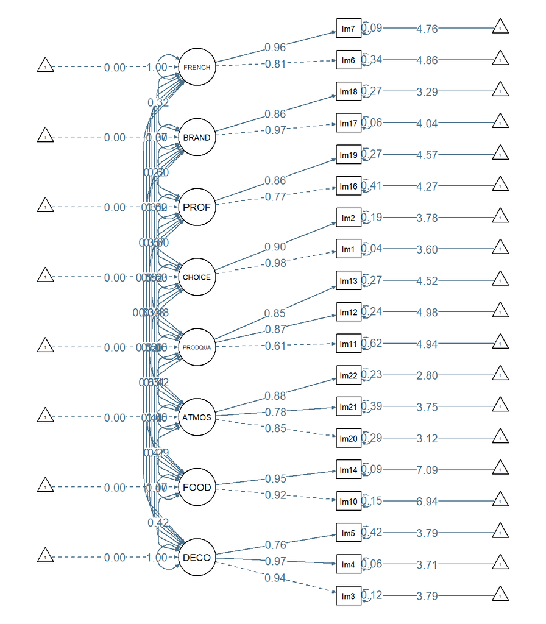

```r
semPaths(fit_CFA, what = "path", whatLabels = "std", style = "mx",
         rotation = 2, layout = "tree3", mar = c(1, 2, 1, 2),
         nCharNodes = 7,shapeMan = "rectangle",
         sizeMan = 4, sizeMan2 = 3, sizeInt = 2, sizeLat = 6, asize = 1.5,
         curvePivot=TRUE, edge.label.cex = .8, edge.color = "skyblue4"
         )
```

## Global fit measures

```r
global_fit_measures <- f_global_fit_measures(fit_CFA)
# check global fit pass/fail of global fit measures
global_fit_measures[[1]]
```

Value

Result

pvalue

0.000

FAIL

chisq

259.047

cfi

0.982

Accept model

rmsea

0.044

Good fit

## Full summary

```r
# output full summary
global_fit_measures[[2]]
```

```
## lavaan 0.6.15 ended normally after 107 iterations
##
##   Estimator                                         ML
##   Optimization method                           NLMINB
##   Number of model parameters                        85
##
##   Number of observations                           553
##   Number of missing patterns                        79
##
## Model Test User Model:
##
##   Test statistic                               259.047
##   Degrees of freedom                               124
##   P-value (Chi-square)                           0.000
##
## Model Test Baseline Model:
##
##   Test statistic                              7474.765
##   Degrees of freedom                               171
##   P-value                                        0.000
##
## User Model versus Baseline Model:
##
##   Comparative Fit Index (CFI)                    0.982
##   Tucker-Lewis Index (TLI)                       0.975
##
##   Robust Comparative Fit Index (CFI)             0.981
##   Robust Tucker-Lewis Index (TLI)                0.974
##
## Loglikelihood and Information Criteria:
##
##   Loglikelihood user model (H0)             -12973.111
##   Loglikelihood unrestricted model (H1)     -12843.588
##
##   Akaike (AIC)                               26116.223
##   Bayesian (BIC)                             26483.028
##   Sample-size adjusted Bayesian (SABIC)      26213.200
##
## Root Mean Square Error of Approximation:
##
```

[output cut: 134 more lines]

```
##    .Im2               0.317    0.044    7.233    0.000    0.317    0.192
##    .Im16              0.599    0.052   11.498    0.000    0.599    0.414
##    .Im19              0.338    0.045    7.457    0.000    0.338    0.267
##    .Im17              0.095    0.045    2.112    0.035    0.095    0.062
##    .Im18              0.521    0.055    9.540    0.000    0.521    0.267
##    .Im6               0.487    0.056    8.677    0.000    0.487    0.339
##    .Im7               0.128    0.067    1.930    0.054    0.128    0.088
##     DECO              1.528    0.107   14.326    0.000    1.000    1.000
##     FOOD              0.659    0.049   13.328    0.000    1.000    1.000
##     ATMOS             1.599    0.138   11.623    0.000    1.000    1.000
##     PRODQUAL          0.494    0.067    7.361    0.000    1.000    1.000
##     CHOICE            1.704    0.118   14.388    0.000    1.000    1.000
##     PROF              0.849    0.088    9.638    0.000    1.000    1.000
##     BRAND             1.451    0.104   13.988    0.000    1.000    1.000
##     FRENCH            0.952    0.095   10.058    0.000    1.000    1.000
```

CFI and RMSEA indicate the factor model is good.

We get a very low p-value indicating the covariance matrix generated by the estimated model does not reproduce the empirical sample covariance matrix S generated by our data. We are not sure why we get such a low p-value and from here onwards we decide to ignore it and focus exclusively on CFI and RMSEA global fit assessments.

## local fit measures

```r
lambda = inspect(fit_CFA, what="std")$lambda
theta = inspect(fit_CFA, what="std")$theta
psi = inspect(fit_CFA, what="std")$psi
```

### Indicator reliability criterion (Individual Item Reliability)

```r
# calculate indicator reliabilities (should be larger than 0.4)
indic_rel <- f_indic_rel(lambda, theta)
# pass/fail
indic_rel[[1]]
```

|  | Result |
| --- | --- |
| Individual Item Reliability | Fail |

```r
# details
indic_rel[[2]]
```

```
##       DECO  FOOD ATMOS PRODQU CHOICE  PROF BRAND FRENCH
## Im3  0.878   NaN   NaN    NaN    NaN   NaN   NaN    NaN
## Im4  0.940   NaN   NaN    NaN    NaN   NaN   NaN    NaN
## Im5  0.578   NaN   NaN    NaN    NaN   NaN   NaN    NaN
## Im10   NaN 0.852   NaN    NaN    NaN   NaN   NaN    NaN
## Im14   NaN 0.907   NaN    NaN    NaN   NaN   NaN    NaN
## Im20   NaN   NaN 0.715    NaN    NaN   NaN   NaN    NaN
## Im21   NaN   NaN 0.614    NaN    NaN   NaN   NaN    NaN
## Im22   NaN   NaN 0.769    NaN    NaN   NaN   NaN    NaN
## Im11   NaN   NaN   NaN  0.378    NaN   NaN   NaN    NaN
## Im12   NaN   NaN   NaN  0.760    NaN   NaN   NaN    NaN
## Im13   NaN   NaN   NaN  0.731    NaN   NaN   NaN    NaN
## Im1    NaN   NaN   NaN    NaN  0.960   NaN   NaN    NaN
## Im2    NaN   NaN   NaN    NaN  0.808   NaN   NaN    NaN
## Im16   NaN   NaN   NaN    NaN    NaN 0.586   NaN    NaN
## Im19   NaN   NaN   NaN    NaN    NaN 0.733   NaN    NaN
## Im17   NaN   NaN   NaN    NaN    NaN   NaN 0.938    NaN
## Im18   NaN   NaN   NaN    NaN    NaN   NaN 0.733    NaN
## Im6    NaN   NaN   NaN    NaN    NaN   NaN   NaN  0.661
## Im7    NaN   NaN   NaN    NaN    NaN   NaN   NaN  0.912
```

We have only one problematic item which is item Im11 with factor *Product Quality* but its Individual Item Reliability is close enough to the 0.4 limit.

### Construct reliability criterion

```r
# calculate construct reliability (should be above .6)
construct_rel <- f_construct_rel(lambda,theta)
# pass/fail
construct_rel[[1]]
```

|  | Result |
| --- | --- |
| Construct Reliability | Pass |

```r
# details
construct_rel[[2]]
```

```
##               DECO      FOOD     ATMOS  PRODQUAL    CHOICE      PROF    BRAND
## DECO     0.9215975       NaN       NaN       NaN       NaN       NaN      NaN
## FOOD           NaN 0.9359401       NaN       NaN       NaN       NaN      NaN
## ATMOS          NaN       NaN 0.8742538       NaN       NaN       NaN      NaN
## PRODQUAL       NaN       NaN       NaN 0.8289772       NaN       NaN      NaN
## CHOICE         NaN       NaN       NaN       NaN 0.9384579       NaN      NaN
## PROF           NaN       NaN       NaN       NaN       NaN 0.7945654      NaN
## BRAND          NaN       NaN       NaN       NaN       NaN       NaN 0.910291
## FRENCH         NaN       NaN       NaN       NaN       NaN       NaN      NaN
##             FRENCH
## DECO           NaN
## FOOD           NaN
## ATMOS          NaN
## PRODQUAL       NaN
## CHOICE         NaN
## PROF           NaN
## BRAND          NaN
## FRENCH   0.8799455
```

### Average Variance Extracted criterion

```r
# calculate Average Variance Extracted (should be above .5)
AVE <- f_AVE(lambda,theta)
# pass/fail
AVE[[1]]
```

|  | Result |
| --- | --- |
| Average Variance Extracted | Pass |

```r
# details
diag(AVE[[2]])
```

```
##      DECO      FOOD     ATMOS  PRODQUAL    CHOICE      PROF     BRAND    FRENCH
## 0.7983935 0.8796192 0.6990218 0.6229771 0.8842422 0.6598501 0.8358722 0.7867068
```

### Construct correlations

```r
# correlations between constructs (factors...) should be lower than .7
construct_cor <- f_construct_corr(psi)
# pass / fail
construct_cor[[1]]
```

|  | Result |
| --- | --- |
| Construct Correlations | Pass |

```r
# details
construct_cor[[2]]
```

```
##           DECO  FOOD ATMOS PRODQU CHOICE  PROF BRAND FRENCH
## DECO     1.000
## FOOD     0.416 1.000
## ATMOS    0.467 0.295 1.000
## PRODQUAL 0.471 0.452 0.418  1.000
## CHOICE   0.441 0.309 0.448  0.478  1.000
## PROF     0.653 0.498 0.478  0.529  0.597 1.000
## BRAND    0.517 0.325 0.516  0.566  0.519 0.601 1.000
## FRENCH   0.334 0.585 0.333  0.306  0.225 0.366 0.322  1.000
```

### Fornell-Larcker Criteria

```r
# AVE should be higher than squared correlations between constructs
fornell_larcker <- f_fornell_larcker(psi,AVE[[2]])
# pass / fail
fornell_larcker[[1]]
```

|  | Result |
| --- | --- |
| Fornell-Larcker Criteria | Pass |

```r
# details (note: AVE is in the diagonals)
fornell_larcker[[2]]
```

```
##           DECO  FOOD ATMOS PRODQU CHOICE  PROF BRAND FRENCH
## DECO     0.798
## FOOD     0.173 0.880
## ATMOS    0.218 0.087 0.699
## PRODQUAL 0.222 0.205 0.175  0.623
## CHOICE   0.194 0.096 0.201  0.228  0.884
## PROF     0.426 0.248 0.228  0.280  0.356 0.660
## BRAND    0.268 0.106 0.267  0.321  0.270 0.361 0.836
## FRENCH   0.111 0.343 0.111  0.093  0.051 0.134 0.104  0.787
```

## Modification indices

```r
arrange(modificationindices(fit_CFA),-mi) |> filter(mi>10)
```

```
##       lhs op  rhs     mi    epc sepc.lv sepc.all sepc.nox
## 1   BRAND =~ Im13 23.832  0.220   0.265    0.220    0.220
## 2    Im11 ~~ Im13 21.323 -0.191  -0.191   -0.338   -0.338
## 3   BRAND =~ Im12 17.245 -0.179  -0.216   -0.190   -0.190
## 4    Im21 ~~ Im22 15.139 -0.285  -0.285   -0.455   -0.455
## 5  CHOICE =~ Im20 14.777 -0.151  -0.197   -0.132   -0.132
## 6  CHOICE =~ Im13 13.970  0.133   0.174    0.144    0.144
## 7    Im11 ~~ Im12 13.307  0.145   0.145    0.288    0.288
## 8    FOOD =~ Im11 12.742  0.215   0.174    0.152    0.152
## 9    Im20 ~~ Im21 11.455  0.228   0.228    0.335    0.335
## 10  ATMOS =~ Im12 10.952 -0.115  -0.145   -0.127   -0.127
## 11   Im13 ~~  Im1 10.708  0.068   0.068    0.409    0.409
## 12 CHOICE =~ Im12 10.663 -0.111  -0.145   -0.127   -0.127
```

All the modification indices are pretty low. In addition, the highest ones would suggest we should move some items around like for example move Im13 to the *Brand Image* factor, but this actually makes the model worse.

So luckily the model found in the exploratory phase is good enough and we decide to stick with these dimensions which again, are the following:

## QUESTION 1: Dimensions by which Galeries Lafayette is perceived

```r
fact_interpretation <- c("Decoration","Gourmet Food","Relaxed Atmosphere",
                    "Product Quality","Choice Range","Brand Image",
                    "Frenchness","Professionalism")

names(fact_interpretation) <- c("MR1","MR2","MR3",
                           "MR4","MR5","MR6",
                           "MR7","MR8")


f_factor_interp(PAFn[["8"]], labels,fact_interpretation)
```

| Variable | Label_short | Loads_on | Interpretation |
| --- | --- | --- | --- |
| Im15 | Professional Selection of Brands |  | excluded |
| Im8 | Expertise in French Traditional Cuisine |  | excluded |
| Im9 | French Fashion |  | excluded |
| Im3 | Artistic Decoration of Sales Area | MR1 | Decoration |
| Im4 | Creative Decoration of Sales Area | MR1 | Decoration |
| Im5 | Appealing Arrangement of Shop Windows | MR1 | Decoration |
| Im10 | Gourmet Food | MR2 | Gourmet Food |
| Im14 | Gourmet specialities | MR2 | Gourmet Food |
| Im20 | Relaxing Shopping | MR3 | Relaxed Atmosphere |
| Im21 | A Great Place to Stroll | MR3 | Relaxed Atmosphere |
| Im22 | Intimate Shop Atmosphere | MR3 | Relaxed Atmosphere |
| Im11 | High-quality Cosmetics | MR4 | Product Quality |
| Im12 | Luxury brands | MR4 | Product Quality |
| Im13 | Up tp date Designer Brands | MR4 | Product Quality |
| Im1 | Large Assortment | MR5 | Choice Range |
| Im2 | Assortment Variety | MR5 | Choice Range |
| Im17 | Are Trendy | MR6 | Brand Image |
| Im18 | Are Hip | MR6 | Brand Image |
| Im6 | France | MR7 | Frenchness |
| Im7 | French Savoir-vivre | MR7 | Frenchness |
| Im16 | Professional Appearance Towards Customers | MR8 | Professionalism |
| Im19 | Professional Organization | MR8 | Professionalism |

# SEM

We now want to understand the effect and importance of these dimensions of perception on two variables of interest for the business *Repurchase intention* and *Co-creation intention*.

Our model will include 2 mediating variables: *Customer Satisfaction* and *Affective Commitment* that interface between the dimensions of perception and variables of interest for the business (the outcome variables of our model).

## ROUND 1

### Model

We start with a full model where perception dimensions can have both direct and indirect effects on the outcome variables.

We include previously excluded variables Im8, Im9, Im15 to see if they might be important for the outcomes. It is not because they cannot be reduced to factors that they cannot potentially be important items influencing the outcomes.

```r
# Full model
model_SEM <- "
DECO =~ Im3 + Im4 + Im5
FOOD =~ Im10 + Im14
ATMOS =~ Im20 + Im21 + Im22
PRODQUAL =~ Im11 + Im12 + Im13
CHOICE =~ Im1 + Im2
PROF =~ Im16 + Im19
BRAND =~ Im17 + Im18
FRENCH =~ Im6 + Im7

AFCOM =~ COM_A1 + COM_A2 + COM_A3 + COM_A4
SAT =~ SAT_1 + SAT_2 + SAT_3
RI =~ C_REP1 + C_REP2 + C_REP3
COI =~ C_CR1 + C_CR3 + C_CR4

SAT ~ s1*DECO + s2*FOOD + s3*ATMOS + s4*PRODQUAL + s5*CHOICE + s6*PROF + s7*BRAND + s8*FRENCH + si8*Im8 + si15*Im15 + si9*Im9
AFCOM ~ a1*DECO + a2*FOOD + a3*ATMOS + a4*PRODQUAL + a5*CHOICE + a6*PROF + a7*BRAND + a8*FRENCH + ai8*Im8 + ai15*Im15 + ai9*Im9

RI ~ rs*SAT + ra*AFCOM + r01*DECO + r02*FOOD + r03*ATMOS + r04*PRODQUAL + r05*CHOICE + r06*PROF + r07*BRAND + r08*FRENCH + r0i8*Im8 + r0i15*Im15 + r0i9*Im9
COI ~ cs*SAT + ca*AFCOM + c01*DECO + c02*FOOD + c03*ATMOS + c04*PRODQUAL + c05*CHOICE + c06*PROF + c07*BRAND + c08*FRENCH + c0i8*Im8 + c0i15*Im15 + c0i9*Im9

rss1:= rs*s1
raa1:= ra*a1
css1:= cs*s1
caa1:= ca*a1
DECOtoRI_total:= r01 + rss1 + raa1
DECOtoCOI_total:= c01 + css1 + caa1

rss2:= rs*s2
raa2:= ra*a2
css2:= cs*s2
caa2:= ca*a2
FOODtoRI_total:= r02 + rss2 + raa2
FOODtoCOI_total:= c02 + css2 + caa2

rss3:= rs*s3
raa3:= ra*a3
css3:= cs*s3
caa3:= ca*a3
ATMOStoRI_total:= r03 + rss3 + raa3
ATMOStoCOI_total:= c03 + css3 + caa3

rss4:= rs*s4
raa4:= ra*a4
css4:= cs*s4
caa4:= ca*a4
PQUALtoRI_total:= r04 + rss4 + raa4
PQUALtoCOI_total:= c04 + css4 + caa4

rss5:= rs*s5
raa5:= ra*a5
css5:= cs*s5
caa5:= ca*a5
CHOICEtoRI_total:= r05 + rss5 + raa5
CHOICEtoCOI_total:= c05 + css5 + caa5

rss6:= rs*s6
raa6:= ra*a6
css6:= cs*s6
caa6:= ca*a6
PROFtoRI_total:= r06 + rss6 + raa6
PROFtoCOI_total:= c06 + css6 + caa6

rss7:= rs*s7
raa7:= ra*a7
css7:= cs*s7
caa7:= ca*a7
BRANDtoRI_total:= r07 + rss7 + raa7
BRANDtoCOI_total:= c07 + css7 + caa7

rss8:= rs*s8
raa8:= ra*a8
css8:= cs*s8
caa8:= ca*a8
FRENCHtoRI_total:= r08 + rss8 + raa8
FRENCHtoCOI_total:= c08 + css8 + caa8

rssi8:= rs*si8
raai8:= ra*ai8
cssi8:= cs*si8
caai8:= ca*ai8
Im8toRI_total:= r0i8 + rssi8 + raai8
Im8toCOI_total:= c0i8 + cssi8 + caai8

rssi9:= rs*si9
raai9:= ra*ai9
cssi9:= cs*si9
caai9:= ca*ai9
Im9toRI_total:= r0i9 + rssi9 + raai9
Im9toCOI_total:= c0i9 + cssi9 + caai9

rssi15:= rs*si15
raai15:= ra*ai15
cssi15:= cs*si15
caai15:= ca*ai15
Im15toRI_total:= r0i15 + rssi15 + raai15
Im15toCOI_total:= c0i15 + cssi15 + caai15
"
```

### Fit

```r
fit_SEM <- cfa(model_SEM, data=survey, missing="ML")
```

### SEM plot

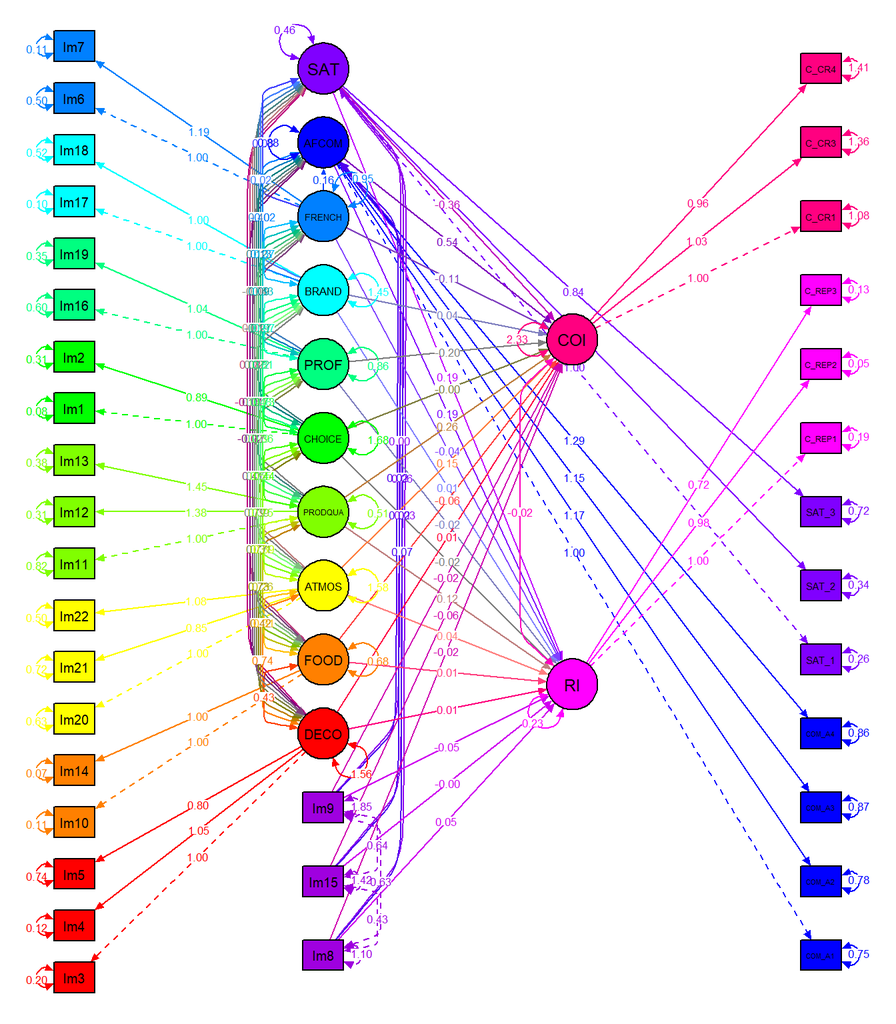

```r
semPaths(fit_SEM, what = "col", whatLabels = "par", style = "ram",
         rotation = 2, layout = "tree3",
         mar = c(1, 2, 1, 2), #margins
         nCharNodes = 7,
         shapeMan = "rectangle", # variable shape
         sizeMan = 4, # variable shape size
         sizeMan2 = 3, # variable shape vertical stretch
         # structural = T, # don't plot image variables (manifests)
         sizeInt = 1, # intercept size
         intercepts = F, # don't include intercepts
         sizeLat = 5, #factor size
         asize = 2, # arrow size
         curvePivot=T, # edge broken curve
         edge.label.cex = .5, # edge label size
         # edge.color = "skyblue4",
         # levels= c(1,2,7,8,9,10),
         groups = "latents",
         cut = .5 #cutoff for edges,
         )
```

Let us now assess this model

### Global fit measures

```r
global_fit_measures <- f_global_fit_measures(fit_SEM)
# check global fit pass/fail of global fit measures
global_fit_measures[[1]]
```

Value

Result

pvalue

0.000

FAIL

chisq

1863.685

cfi

0.886

Definitely reject the model

rmsea

0.074

Acceptable fit

### Regression results and full summary

```r
# output full summary
global_fit_measures[[2]]
```

```
## lavaan 0.6.15 ended normally after 178 iterations
##
##   Estimator                                         ML
##   Optimization method                           NLMINB
##   Number of model parameters                       173
##
##                                                   Used       Total
##   Number of observations                           523         553
##   Number of missing patterns                       116
##
## Model Test User Model:
##
##   Test statistic                              1863.685
##   Degrees of freedom                               483
##   P-value (Chi-square)                           0.000
##
## Model Test Baseline Model:
##
##   Test statistic                             12715.671
##   Degrees of freedom                               592
##   P-value                                        0.000
##
## User Model versus Baseline Model:
##
##   Comparative Fit Index (CFI)                    0.886
##   Tucker-Lewis Index (TLI)                       0.860
##
##   Robust Comparative Fit Index (CFI)             0.888
##   Robust Tucker-Lewis Index (TLI)                0.863
##
## Loglikelihood and Information Criteria:
##
##   Loglikelihood user model (H0)             -21205.949
##   Loglikelihood unrestricted model (H1)     -20274.106
##
##   Akaike (AIC)                               42757.897
##   Bayesian (BIC)                             43494.805
##   Sample-size adjusted Bayesian (SABIC)      42945.662
##
## Root Mean Square Error of Approximation:
```

[output cut: 312 more lines]

```
##     caai8             0.036    0.039    0.923    0.356    0.021    0.023
##     Im8toRI_total     0.065    0.039    1.666    0.096    0.111    0.117
##     Im8toCOI_total    0.008    0.122    0.068    0.946    0.005    0.005
##     rssi9             0.000    0.006    0.073    0.942    0.001    0.001
##     raai9             0.004    0.008    0.506    0.613    0.007    0.010
##     cssi9            -0.001    0.012   -0.073    0.942   -0.001   -0.001
##     caai9             0.012    0.024    0.506    0.613    0.007    0.010
##     Im9toRI_total    -0.043    0.024   -1.782    0.075   -0.073   -0.099
##     Im9toCOI_total   -0.005    0.075   -0.063    0.950   -0.003   -0.004
##     rssi15            0.011    0.009    1.212    0.226    0.019    0.022
##     raai15            0.004    0.011    0.400    0.689    0.008    0.009
##     cssi15           -0.021    0.018   -1.137    0.256   -0.012   -0.015
##     caai15            0.013    0.032    0.400    0.689    0.008    0.009
##     Im15toRI_total    0.011    0.033    0.330    0.742    0.018    0.022
##     Im15toCOI_totl   -0.065    0.102   -0.631    0.528   -0.038   -0.046
```

### local fit measures

```r
lambda = inspect(fit_SEM, what="std")$lambda
theta = inspect(fit_SEM, what="std")$theta
psi = inspect(fit_SEM, what="std")$psi
```

#### Indicator reliability criterion (Individual Item Reliability)

```r
# calculate indicator reliabilities (should be larger than 0.4)
indic_rel <- f_indic_rel(lambda, theta)
# pass/fail
indic_rel[[1]]
```

|  | Result |
| --- | --- |
| Individual Item Reliability | Fail |

```r
# details
indic_rel[[2]]
```

```
##         DECO  FOOD ATMOS PRODQU CHOICE  PROF BRAND FRENCH AFCOM   SAT    RI
## Im3    0.887   NaN   NaN    NaN    NaN   NaN   NaN    NaN   NaN   NaN   NaN
## Im4    0.936   NaN   NaN    NaN    NaN   NaN   NaN    NaN   NaN   NaN   NaN
## Im5    0.573   NaN   NaN    NaN    NaN   NaN   NaN    NaN   NaN   NaN   NaN
## Im10     NaN 0.859   NaN    NaN    NaN   NaN   NaN    NaN   NaN   NaN   NaN
## Im14     NaN 0.909   NaN    NaN    NaN   NaN   NaN    NaN   NaN   NaN   NaN
## Im20     NaN   NaN 0.715    NaN    NaN   NaN   NaN    NaN   NaN   NaN   NaN
## Im21     NaN   NaN 0.613    NaN    NaN   NaN   NaN    NaN   NaN   NaN   NaN
## Im22     NaN   NaN 0.785    NaN    NaN   NaN   NaN    NaN   NaN   NaN   NaN
## Im11     NaN   NaN   NaN  0.383    NaN   NaN   NaN    NaN   NaN   NaN   NaN
## Im12     NaN   NaN   NaN  0.761    NaN   NaN   NaN    NaN   NaN   NaN   NaN
## Im13     NaN   NaN   NaN  0.736    NaN   NaN   NaN    NaN   NaN   NaN   NaN
## Im1      NaN   NaN   NaN    NaN  0.952   NaN   NaN    NaN   NaN   NaN   NaN
## Im2      NaN   NaN   NaN    NaN  0.808   NaN   NaN    NaN   NaN   NaN   NaN
## Im16     NaN   NaN   NaN    NaN    NaN 0.591   NaN    NaN   NaN   NaN   NaN
## Im19     NaN   NaN   NaN    NaN    NaN 0.730   NaN    NaN   NaN   NaN   NaN
## Im17     NaN   NaN   NaN    NaN    NaN   NaN 0.937    NaN   NaN   NaN   NaN
## Im18     NaN   NaN   NaN    NaN    NaN   NaN 0.735    NaN   NaN   NaN   NaN
## Im6      NaN   NaN   NaN    NaN    NaN   NaN   NaN  0.656   NaN   NaN   NaN
## Im7      NaN   NaN   NaN    NaN    NaN   NaN   NaN  0.923   NaN   NaN   NaN
## COM_A1   NaN   NaN   NaN    NaN    NaN   NaN   NaN    NaN 0.623   NaN   NaN
## COM_A2   NaN   NaN   NaN    NaN    NaN   NaN   NaN    NaN 0.688   NaN   NaN
## COM_A3   NaN   NaN   NaN    NaN    NaN   NaN   NaN    NaN 0.657   NaN   NaN
## COM_A4   NaN   NaN   NaN    NaN    NaN   NaN   NaN    NaN 0.706   NaN   NaN
## SAT_1    NaN   NaN   NaN    NaN    NaN   NaN   NaN    NaN   NaN 0.732   NaN
## SAT_2    NaN   NaN   NaN    NaN    NaN   NaN   NaN    NaN   NaN 0.651   NaN
## SAT_3    NaN   NaN   NaN    NaN    NaN   NaN   NaN    NaN   NaN 0.414   NaN
## C_REP1   NaN   NaN   NaN    NaN    NaN   NaN   NaN    NaN   NaN   NaN 0.650
## C_REP2   NaN   NaN   NaN    NaN    NaN   NaN   NaN    NaN   NaN   NaN 0.872
## C_REP3   NaN   NaN   NaN    NaN    NaN   NaN   NaN    NaN   NaN   NaN 0.580
## C_CR1    NaN   NaN   NaN    NaN    NaN   NaN   NaN    NaN   NaN   NaN   NaN
## C_CR3    NaN   NaN   NaN    NaN    NaN   NaN   NaN    NaN   NaN   NaN   NaN
## C_CR4    NaN   NaN   NaN    NaN    NaN   NaN   NaN    NaN   NaN   NaN   NaN
## Im8      NaN   NaN   NaN    NaN    NaN   NaN   NaN    NaN   NaN   NaN   NaN
## Im15     NaN   NaN   NaN    NaN    NaN   NaN   NaN    NaN   NaN   NaN   NaN
## Im9      NaN   NaN   NaN    NaN    NaN   NaN   NaN    NaN   NaN   NaN   NaN
##          COI Im8 Im15 Im9
## Im3      NaN NaN  NaN NaN
## Im4      NaN NaN  NaN NaN
## Im5      NaN NaN  NaN NaN
```

[output cut: 17 more lines]

```
## COM_A2   NaN NaN  NaN NaN
## COM_A3   NaN NaN  NaN NaN
## COM_A4   NaN NaN  NaN NaN
## SAT_1    NaN NaN  NaN NaN
## SAT_2    NaN NaN  NaN NaN
## SAT_3    NaN NaN  NaN NaN
## C_REP1   NaN NaN  NaN NaN
## C_REP2   NaN NaN  NaN NaN
## C_REP3   NaN NaN  NaN NaN
## C_CR1  0.724 NaN  NaN NaN
## C_CR3  0.687 NaN  NaN NaN
## C_CR4  0.647 NaN  NaN NaN
## Im8      NaN   1  NaN NaN
## Im15     NaN NaN    1 NaN
## Im9      NaN NaN  NaN   1
```

#### Construct reliability criterion

```r
# calculate construct reliability (should be above .6)
construct_rel <- f_construct_rel(lambda,theta)
# pass/fail
construct_rel[[1]]
```

|  | Result |
| --- | --- |
| Construct Reliability | Pass |

```r
# details
construct_rel[[2]]
```

```
##               DECO     FOOD     ATMOS  PRODQUAL   CHOICE      PROF     BRAND
## DECO     0.9216861      NaN       NaN       NaN      NaN       NaN       NaN
## FOOD           NaN 0.938467       NaN       NaN      NaN       NaN       NaN
## ATMOS          NaN      NaN 0.8769272       NaN      NaN       NaN       NaN
## PRODQUAL       NaN      NaN       NaN 0.8312695      NaN       NaN       NaN
## CHOICE         NaN      NaN       NaN       NaN 0.936156       NaN       NaN
## PROF           NaN      NaN       NaN       NaN      NaN 0.7947444       NaN
## BRAND          NaN      NaN       NaN       NaN      NaN       NaN 0.9102654
## FRENCH         NaN      NaN       NaN       NaN      NaN       NaN       NaN
## AFCOM          NaN      NaN       NaN       NaN      NaN       NaN       NaN
## SAT            NaN      NaN       NaN       NaN      NaN       NaN       NaN
## RI             NaN      NaN       NaN       NaN      NaN       NaN       NaN
## COI            NaN      NaN       NaN       NaN      NaN       NaN       NaN
## Im8            NaN      NaN       NaN       NaN      NaN       NaN       NaN
## Im15           NaN      NaN       NaN       NaN      NaN       NaN       NaN
## Im9            NaN      NaN       NaN       NaN      NaN       NaN       NaN
##             FRENCH     AFCOM       SAT        RI       COI Im8 Im15 Im9
## DECO           NaN       NaN       NaN       NaN       NaN NaN  NaN NaN
## FOOD           NaN       NaN       NaN       NaN       NaN NaN  NaN NaN
## ATMOS          NaN       NaN       NaN       NaN       NaN NaN  NaN NaN
## PRODQUAL       NaN       NaN       NaN       NaN       NaN NaN  NaN NaN
## CHOICE         NaN       NaN       NaN       NaN       NaN NaN  NaN NaN
## PROF           NaN       NaN       NaN       NaN       NaN NaN  NaN NaN
## BRAND          NaN       NaN       NaN       NaN       NaN NaN  NaN NaN
## FRENCH   0.8815251       NaN       NaN       NaN       NaN NaN  NaN NaN
## AFCOM          NaN 0.8896814       NaN       NaN       NaN NaN  NaN NaN
## SAT            NaN       NaN 0.8154708       NaN       NaN NaN  NaN NaN
## RI             NaN       NaN       NaN 0.8744048       NaN NaN  NaN NaN
## COI            NaN       NaN       NaN       NaN 0.8677625 NaN  NaN NaN
## Im8            NaN       NaN       NaN       NaN       NaN   1  NaN NaN
## Im15           NaN       NaN       NaN       NaN       NaN NaN    1 NaN
## Im9            NaN       NaN       NaN       NaN       NaN NaN  NaN   1
```

#### Average Variance Extracted criterion

```r
# calculate Average Variance Extracted (should be above .5)
AVE <- f_AVE(lambda,theta)
# pass/fail
AVE[[1]]
```

|  | Result |
| --- | --- |
| Average Variance Extracted | Pass |

```r
# details
diag(AVE[[2]])
```

```
##      DECO      FOOD     ATMOS  PRODQUAL    CHOICE      PROF     BRAND    FRENCH
## 0.7986540 0.8840886 0.7042436 0.6266578 0.8801529 0.6600242 0.8358152 0.7893475
##     AFCOM       SAT        RI       COI       Im8      Im15       Im9
## 0.6685777 0.5989778 0.7004641 0.6863763 1.0000000 1.0000000 1.0000000
```

#### Construct correlations

```r
# correlations between constructs (factors...) should be lower than .7
construct_cor <- f_construct_corr(psi)
# pass / fail
construct_cor[[1]]
```

|  | Result |
| --- | --- |
| Construct Correlations | Pass |

```r
# details
construct_cor[[2]]
```

```
##            DECO   FOOD  ATMOS PRODQU CHOICE   PROF  BRAND FRENCH  AFCOM    SAT
## DECO      1.000
## FOOD      0.414  1.000
## ATMOS     0.471  0.298  1.000
## PRODQUAL  0.471  0.448  0.435  1.000
## CHOICE    0.452  0.291  0.462  0.480  1.000
## PROF      0.662  0.505  0.475  0.541  0.605  1.000
## BRAND     0.523  0.325  0.526  0.561  0.516  0.601  1.000
## FRENCH    0.337  0.587  0.334  0.313  0.215  0.367  0.318  1.000
## AFCOM     0.000  0.000  0.000  0.000  0.000  0.000  0.000  0.000  0.710
## SAT       0.000  0.000  0.000  0.000  0.000  0.000  0.000  0.000  0.000  0.642
## RI        0.000  0.000  0.000  0.000  0.000  0.000  0.000  0.000  0.000  0.000
## COI       0.000  0.000  0.000  0.000  0.000  0.000  0.000  0.000  0.000  0.000
## Im8       0.000  0.000  0.000  0.000  0.000  0.000  0.000  0.000  0.000  0.000
## Im15      0.000  0.000  0.000  0.000  0.000  0.000  0.000  0.000  0.000  0.000
## Im9       0.000  0.000  0.000  0.000  0.000  0.000  0.000  0.000  0.000  0.000
##              RI    COI    Im8   Im15    Im9
## DECO
## FOOD
## ATMOS
## PRODQUAL
## CHOICE
## PROF
## BRAND
## FRENCH
## AFCOM
## SAT
## RI        0.672
## COI      -0.034  0.824
## Im8       0.000  0.000  1.000
## Im15      0.000  0.000  0.342  1.000
## Im9       0.000  0.000  0.442  0.397  1.000
```

#### Fornell-Larcker Criteria

```r
# AVE should be higher than squared correlations between constructs
fornell_larcker <- f_fornell_larcker(psi,AVE[[2]])
# pass / fail
fornell_larcker[[1]]
```

|  | Result |
| --- | --- |
| Fornell-Larcker Criteria | Pass |

```r
# details (note: AVE is in the diagonals)
fornell_larcker[[2]]
```

```
##           DECO  FOOD ATMOS PRODQU CHOICE  PROF BRAND FRENCH AFCOM   SAT    RI
## DECO     0.799
## FOOD     0.172 0.884
## ATMOS    0.222 0.089 0.704
## PRODQUAL 0.222 0.201 0.189  0.627
## CHOICE   0.204 0.085 0.213  0.230  0.880
## PROF     0.438 0.255 0.225  0.293  0.366 0.660
## BRAND    0.273 0.106 0.276  0.315  0.266 0.361 0.836
## FRENCH   0.113 0.344 0.111  0.098  0.046 0.135 0.101  0.789
## AFCOM    0.000 0.000 0.000  0.000  0.000 0.000 0.000  0.000 0.669
## SAT      0.000 0.000 0.000  0.000  0.000 0.000 0.000  0.000 0.000 0.599
## RI       0.000 0.000 0.000  0.000  0.000 0.000 0.000  0.000 0.000 0.000 0.700
## COI      0.000 0.000 0.000  0.000  0.000 0.000 0.000  0.000 0.000 0.000 0.001
## Im8      0.000 0.000 0.000  0.000  0.000 0.000 0.000  0.000 0.000 0.000 0.000
## Im15     0.000 0.000 0.000  0.000  0.000 0.000 0.000  0.000 0.000 0.000 0.000
## Im9      0.000 0.000 0.000  0.000  0.000 0.000 0.000  0.000 0.000 0.000 0.000
##            COI   Im8  Im15   Im9
## DECO
## FOOD
## ATMOS
## PRODQUAL
## CHOICE
## PROF
## BRAND
## FRENCH
## AFCOM
## SAT
## RI
## COI      0.686
## Im8      0.000 1.000
## Im15     0.000 0.117 1.000
## Im9      0.000 0.195 0.158 1.000
```

### Modification indices

```r
arrange(modificationindices(fit_SEM),-mi) |> filter(mi>10)
```

```
##         lhs op      rhs      mi    epc sepc.lv sepc.all sepc.nox
## 1      Im15  ~   CHOICE 183.159  0.499   0.648    0.543    0.543
## 2       Im8  ~     FOOD 165.172  0.650   0.534    0.509    0.509
## 3      Im15  ~     PROF 144.404  0.658   0.611    0.513    0.513
## 4      Im15  ~      SAT 141.620  1.178   0.996    0.836    0.836
## 5       Im8  ~   FRENCH 131.111  0.492   0.480    0.457    0.457
## 6      Im15  ~       RI 126.702  2.198   1.291    1.084    1.084
## 7      Im15  ~    BRAND  87.447  0.374   0.451    0.378    0.378
## 8      Im15  ~ PRODQUAL  85.387  0.649   0.463    0.388    0.388
## 9      Im15  ~    AFCOM  76.869  0.727   0.811    0.681    0.681
## 10     Im15  ~     DECO  69.835  0.321   0.400    0.336    0.336
## 11     Im15  ~    ATMOS  68.865  0.328   0.412    0.346    0.346
## 12     FOOD  ~      Im8  65.016  0.219   0.266    0.280    0.266
## 13   FRENCH  ~      Im8  60.450  0.269   0.276    0.289    0.276
## 14    AFCOM =~   C_REP1  59.740  0.185   0.207    0.284    0.284
```

[output cut: 66 more lines]

### Discussion

This model is not great, it fails the global fit measures.

The highest modification indices are all relating to Im8 and Im15. In order improve the model we do a second round and exclude them.

## ROUND 2

### Model

```r
# excluded out Im8 and Im15
model_SEM <- "
DECO =~ Im3 + Im4 + Im5
FOOD =~ Im10 + Im14
ATMOS =~ Im20 + Im21 + Im22
PRODQUAL =~ Im11 + Im12 + Im13
CHOICE =~ Im1 + Im2
PROF =~ Im16 + Im19
BRAND =~ Im17 + Im18
FRENCH =~ Im6 + Im7

AFCOM =~ COM_A1 + COM_A2 + COM_A3 + COM_A4
SAT =~ SAT_1 + SAT_2 + SAT_3
RI =~ C_REP1 + C_REP2 + C_REP3
COI =~ C_CR1 + C_CR3 + C_CR4

SAT ~ s1*DECO + s2*FOOD + s3*ATMOS + s4*PRODQUAL + s5*CHOICE + s6*PROF + s7*BRAND + s8*FRENCH + si9*Im9
AFCOM ~ a1*DECO + a2*FOOD + a3*ATMOS + a4*PRODQUAL + a5*CHOICE + a6*PROF + a7*BRAND + a8*FRENCH + ai9*Im9

RI ~ rs*SAT + ra*AFCOM + r01*DECO + r02*FOOD + r03*ATMOS + r04*PRODQUAL + r05*CHOICE + r06*PROF + r07*BRAND + r08*FRENCH + r0i9*Im9
COI ~ cs*SAT + ca*AFCOM + c01*DECO + c02*FOOD + c03*ATMOS + c04*PRODQUAL + c05*CHOICE + c06*PROF + c07*BRAND + c08*FRENCH + c0i9*Im9

rss1:= rs*s1
raa1:= ra*a1
css1:= cs*s1
caa1:= ca*a1
DECOtoRI_total:= r01 + rss1 + raa1
DECOtoCOI_total:= c01 + css1 + caa1

rss2:= rs*s2
raa2:= ra*a2
css2:= cs*s2
caa2:= ca*a2
FOODtoRI_total:= r02 + rss2 + raa2
FOODtoCOI_total:= c02 + css2 + caa2

rss3:= rs*s3
raa3:= ra*a3
css3:= cs*s3
caa3:= ca*a3
ATMOStoRI_total:= r03 + rss3 + raa3
ATMOStoCOI_total:= c03 + css3 + caa3

rss4:= rs*s4
raa4:= ra*a4
css4:= cs*s4
caa4:= ca*a4
PQUALtoRI_total:= r04 + rss4 + raa4
PQUALtoCOI_total:= c04 + css4 + caa4

rss5:= rs*s5
raa5:= ra*a5
css5:= cs*s5
caa5:= ca*a5
CHOICEtoRI_total:= r05 + rss5 + raa5
CHOICEtoCOI_total:= c05 + css5 + caa5

rss6:= rs*s6
raa6:= ra*a6
css6:= cs*s6
caa6:= ca*a6
PROFtoRI_total:= r06 + rss6 + raa6
PROFtoCOI_total:= c06 + css6 + caa6

rss7:= rs*s7
raa7:= ra*a7
css7:= cs*s7
caa7:= ca*a7
BRANDtoRI_total:= r07 + rss7 + raa7
BRANDtoCOI_total:= c07 + css7 + caa7

rss8:= rs*s8
raa8:= ra*a8
css8:= cs*s8
caa8:= ca*a8
FRENCHtoRI_total:= r08 + rss8 + raa8
FRENCHtoCOI_total:= c08 + css8 + caa8

rssi9:= rs*si9
raai9:= ra*ai9
cssi9:= cs*si9
caai9:= ca*ai9
Im9toRI_total:= r0i9 + rssi9 + raai9
Im9toCOI_total:= c0i9 + cssi9 + caai9
"
```

### Fit

```r
fit_SEM <- cfa(model_SEM, data=survey, missing="ML")
```

### SEM plot

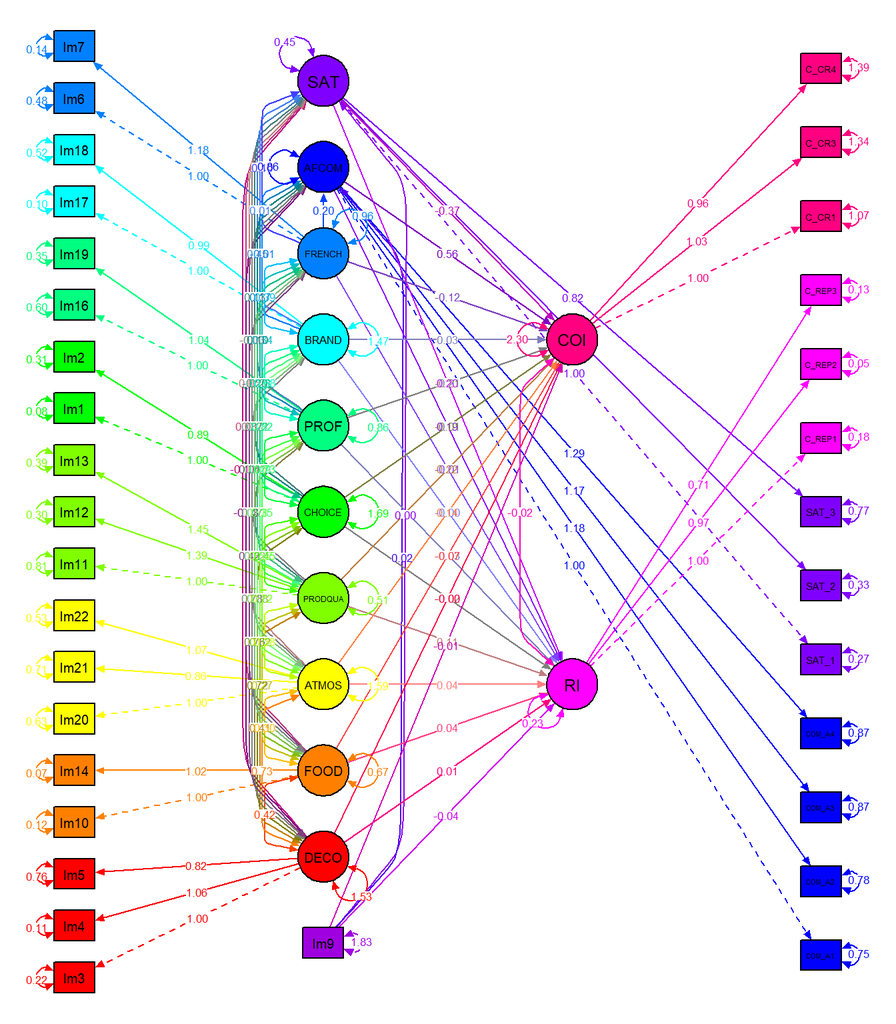

```r
semPaths(fit_SEM, what = "col", whatLabels = "par", style = "ram",
         rotation = 2, layout = "tree3",
         mar = c(1, 2, 1, 2), #margins
         nCharNodes = 7,
         shapeMan = "rectangle", # variable shape
         sizeMan = 4, # variable shape size
         sizeMan2 = 3, # variable shape vertical stretch
         # structural = T, # don't plot image variables (manifests)
         sizeInt = 1, # intercept size
         intercepts = F, # don't include intercepts
         sizeLat = 5, #factor size
         asize = 2, # arrow size
         curvePivot=T, # edge broken curve
         edge.label.cex = .5, # edge label size
         # edge.color = "skyblue4",
         # levels= c(1,2,7,8,9,10),
         groups = "latents",
         cut = .5 #cutoff for edges,
         )
```

Let us now assess this model

### Global fit measures

```r
global_fit_measures <- f_global_fit_measures(fit_SEM)
# check global fit pass/fail of global fit measures
global_fit_measures[[1]]
```

Value

Result

pvalue

0.000

FAIL

chisq

1018.281

cfi

0.949

High under-rejection rate

rmsea

0.051

Acceptable fit

### Regression results and full summary

```r
# output full summary
global_fit_measures[[2]]
```

```
## lavaan 0.6.15 ended normally after 156 iterations
##
##   Estimator                                         ML
##   Optimization method                           NLMINB
##   Number of model parameters                       165
##
##                                                   Used       Total
##   Number of observations                           537         553
##   Number of missing patterns                       124
##
## Model Test User Model:
##
##   Test statistic                              1018.281
##   Degrees of freedom                               427
##   P-value (Chi-square)                           0.000
##
## Model Test Baseline Model:
##
##   Test statistic                             12060.146
##   Degrees of freedom                               528
##   P-value                                        0.000
##
## User Model versus Baseline Model:
##
##   Comparative Fit Index (CFI)                    0.949
##   Tucker-Lewis Index (TLI)                       0.937
##
##   Robust Comparative Fit Index (CFI)             0.950
##   Robust Tucker-Lewis Index (TLI)                0.938
##
## Loglikelihood and Information Criteria:
##
##   Loglikelihood user model (H0)             -21744.301
##   Loglikelihood unrestricted model (H1)     -21235.160
##
##   Akaike (AIC)                               43818.601
##   Bayesian (BIC)                             44525.791
##   Sample-size adjusted Bayesian (SABIC)      44002.025
##
## Root Mean Square Error of Approximation:
```

[output cut: 292 more lines]

```
##     caa7             -0.008    0.033   -0.228    0.820   -0.005   -0.005
##     BRANDtoRI_totl   -0.001    0.032   -0.036    0.971   -0.002   -0.002
##     BRANDtoCOI_ttl    0.018    0.099    0.186    0.853    0.013    0.013
##     rss8              0.019    0.011    1.674    0.094    0.031    0.031
##     raa8              0.037    0.014    2.591    0.010    0.059    0.059
##     css8             -0.036    0.023   -1.516    0.130   -0.021   -0.021
##     caa8              0.111    0.043    2.581    0.010    0.065    0.065
##     FRENCHtoRI_ttl    0.043    0.038    1.117    0.264    0.069    0.069
##     FRENCHtCOI_ttl   -0.041    0.116   -0.349    0.727   -0.024   -0.024
##     rssi9             0.001    0.007    0.104    0.917    0.001    0.002
##     raai9             0.004    0.008    0.526    0.599    0.007    0.009
##     cssi9            -0.001    0.012   -0.104    0.918   -0.001   -0.001
##     caai9             0.013    0.024    0.526    0.599    0.008    0.010
##     Im9toRI_total    -0.038    0.024   -1.620    0.105   -0.063   -0.085
##     Im9toCOI_total   -0.002    0.073   -0.023    0.982   -0.001   -0.001
```

### local fit measures

```r
lambda = inspect(fit_SEM, what="std")$lambda
theta = inspect(fit_SEM, what="std")$theta
psi = inspect(fit_SEM, what="std")$psi
```

#### Indicator reliability criterion (Individual Item Reliability)

```r
# calculate indicator reliabilities (should be larger than 0.4)
indic_rel <- f_indic_rel(lambda, theta)
# pass/fail
indic_rel[[1]]
```

|  | Result |
| --- | --- |
| Individual Item Reliability | Fail |

```r
# details
indic_rel[[2]]
```

```
##         DECO  FOOD ATMOS PRODQU CHOICE  PROF BRAND FRENCH AFCOM   SAT    RI
## Im3    0.876   NaN   NaN    NaN    NaN   NaN   NaN    NaN   NaN   NaN   NaN
## Im4    0.940   NaN   NaN    NaN    NaN   NaN   NaN    NaN   NaN   NaN   NaN
## Im5    0.575   NaN   NaN    NaN    NaN   NaN   NaN    NaN   NaN   NaN   NaN
## Im10     NaN 0.853   NaN    NaN    NaN   NaN   NaN    NaN   NaN   NaN   NaN
## Im14     NaN 0.908   NaN    NaN    NaN   NaN   NaN    NaN   NaN   NaN   NaN
## Im20     NaN   NaN 0.714    NaN    NaN   NaN   NaN    NaN   NaN   NaN   NaN
## Im21     NaN   NaN 0.621    NaN    NaN   NaN   NaN    NaN   NaN   NaN   NaN
## Im22     NaN   NaN 0.772    NaN    NaN   NaN   NaN    NaN   NaN   NaN   NaN
## Im11     NaN   NaN   NaN  0.386    NaN   NaN   NaN    NaN   NaN   NaN   NaN
## Im12     NaN   NaN   NaN  0.766    NaN   NaN   NaN    NaN   NaN   NaN   NaN
## Im13     NaN   NaN   NaN  0.736    NaN   NaN   NaN    NaN   NaN   NaN   NaN
## Im1      NaN   NaN   NaN    NaN  0.953   NaN   NaN    NaN   NaN   NaN   NaN
## Im2      NaN   NaN   NaN    NaN  0.812   NaN   NaN    NaN   NaN   NaN   NaN
## Im16     NaN   NaN   NaN    NaN    NaN 0.589   NaN    NaN   NaN   NaN   NaN
## Im19     NaN   NaN   NaN    NaN    NaN 0.726   NaN    NaN   NaN   NaN   NaN
## Im17     NaN   NaN   NaN    NaN    NaN   NaN 0.937    NaN   NaN   NaN   NaN
## Im18     NaN   NaN   NaN    NaN    NaN   NaN 0.738    NaN   NaN   NaN   NaN
## Im6      NaN   NaN   NaN    NaN    NaN   NaN   NaN  0.667   NaN   NaN   NaN
## Im7      NaN   NaN   NaN    NaN    NaN   NaN   NaN  0.908   NaN   NaN   NaN
## COM_A1   NaN   NaN   NaN    NaN    NaN   NaN   NaN    NaN 0.630   NaN   NaN
## COM_A2   NaN   NaN   NaN    NaN    NaN   NaN   NaN    NaN 0.694   NaN   NaN
## COM_A3   NaN   NaN   NaN    NaN    NaN   NaN   NaN    NaN 0.669   NaN   NaN
## COM_A4   NaN   NaN   NaN    NaN    NaN   NaN   NaN    NaN 0.710   NaN   NaN
## SAT_1    NaN   NaN   NaN    NaN    NaN   NaN   NaN    NaN   NaN 0.743   NaN
## SAT_2    NaN   NaN   NaN    NaN    NaN   NaN   NaN    NaN   NaN 0.671   NaN
## SAT_3    NaN   NaN   NaN    NaN    NaN   NaN   NaN    NaN   NaN 0.405   NaN
## C_REP1   NaN   NaN   NaN    NaN    NaN   NaN   NaN    NaN   NaN   NaN 0.667
## C_REP2   NaN   NaN   NaN    NaN    NaN   NaN   NaN    NaN   NaN   NaN 0.878
## C_REP3   NaN   NaN   NaN    NaN    NaN   NaN   NaN    NaN   NaN   NaN 0.588
## C_CR1    NaN   NaN   NaN    NaN    NaN   NaN   NaN    NaN   NaN   NaN   NaN
## C_CR3    NaN   NaN   NaN    NaN    NaN   NaN   NaN    NaN   NaN   NaN   NaN
## C_CR4    NaN   NaN   NaN    NaN    NaN   NaN   NaN    NaN   NaN   NaN   NaN
## Im9      NaN   NaN   NaN    NaN    NaN   NaN   NaN    NaN   NaN   NaN   NaN
##          COI Im9
## Im3      NaN NaN
## Im4      NaN NaN
## Im5      NaN NaN
## Im10     NaN NaN
## Im14     NaN NaN
```

[output cut: 13 more lines]

```
## Im7      NaN NaN
## COM_A1   NaN NaN
## COM_A2   NaN NaN
## COM_A3   NaN NaN
## COM_A4   NaN NaN
## SAT_1    NaN NaN
## SAT_2    NaN NaN
## SAT_3    NaN NaN
## C_REP1   NaN NaN
## C_REP2   NaN NaN
## C_REP3   NaN NaN
## C_CR1  0.723 NaN
## C_CR3  0.691 NaN
## C_CR4  0.650 NaN
## Im9      NaN   1
```

#### Construct reliability criterion

```r
# calculate construct reliability (should be above .6)
construct_rel <- f_construct_rel(lambda,theta)
# pass/fail
construct_rel[[1]]
```

|  | Result |
| --- | --- |
| Construct Reliability | Pass |

```r
# details
construct_rel[[2]]
```

```
##               DECO      FOOD     ATMOS  PRODQUAL    CHOICE      PROF     BRAND
## DECO     0.9211495       NaN       NaN       NaN       NaN       NaN       NaN
## FOOD           NaN 0.9363902       NaN       NaN       NaN       NaN       NaN
## ATMOS          NaN       NaN 0.8760786       NaN       NaN       NaN       NaN
## PRODQUAL       NaN       NaN       NaN 0.8330218       NaN       NaN       NaN
## CHOICE         NaN       NaN       NaN       NaN 0.9374431       NaN       NaN
## PROF           NaN       NaN       NaN       NaN       NaN 0.7929737       NaN
## BRAND          NaN       NaN       NaN       NaN       NaN       NaN 0.9111648
## FRENCH         NaN       NaN       NaN       NaN       NaN       NaN       NaN
## AFCOM          NaN       NaN       NaN       NaN       NaN       NaN       NaN
## SAT            NaN       NaN       NaN       NaN       NaN       NaN       NaN
## RI             NaN       NaN       NaN       NaN       NaN       NaN       NaN
## COI            NaN       NaN       NaN       NaN       NaN       NaN       NaN
## Im9            NaN       NaN       NaN       NaN       NaN       NaN       NaN
##            FRENCH     AFCOM      SAT        RI       COI Im9
## DECO          NaN       NaN      NaN       NaN       NaN NaN
## FOOD          NaN       NaN      NaN       NaN       NaN NaN
## ATMOS         NaN       NaN      NaN       NaN       NaN NaN
## PRODQUAL      NaN       NaN      NaN       NaN       NaN NaN
## CHOICE        NaN       NaN      NaN       NaN       NaN NaN
## PROF          NaN       NaN      NaN       NaN       NaN NaN
## BRAND         NaN       NaN      NaN       NaN       NaN NaN
## FRENCH   0.880507       NaN      NaN       NaN       NaN NaN
## AFCOM         NaN 0.8929799      NaN       NaN       NaN NaN
## SAT           NaN       NaN 0.819632       NaN       NaN NaN
## RI            NaN       NaN      NaN 0.8797294       NaN NaN
## COI           NaN       NaN      NaN       NaN 0.8685042 NaN
## Im9           NaN       NaN      NaN       NaN       NaN   1
```

#### Average Variance Extracted criterion

```r
# calculate Average Variance Extracted (should be above .5)
AVE <- f_AVE(lambda,theta)
# pass/fail
AVE[[1]]
```

|  | Result |
| --- | --- |
| Average Variance Extracted | Pass |

```r
# details
diag(AVE[[2]])
```

```
##      DECO      FOOD     ATMOS  PRODQUAL    CHOICE      PROF     BRAND    FRENCH
## 0.7974248 0.8804152 0.7024908 0.6295154 0.8824164 0.6575775 0.8373090 0.7875128
##     AFCOM       SAT        RI       COI       Im9
## 0.6760688 0.6061532 0.7106341 0.6877590 1.0000000
```

#### Construct correlations

```r
# correlations between constructs (factors...) should be lower than .7
construct_cor <- f_construct_corr(psi)
# pass / fail
construct_cor[[1]]
```

|  | Result |
| --- | --- |
| Construct Correlations | Pass |

```r
# details
construct_cor[[2]]
```

```
##            DECO   FOOD  ATMOS PRODQU CHOICE   PROF  BRAND FRENCH  AFCOM    SAT
## DECO      1.000
## FOOD      0.415  1.000
## ATMOS     0.470  0.292  1.000
## PRODQUAL  0.463  0.456  0.419  1.000
## CHOICE    0.445  0.302  0.443  0.484  1.000
## PROF      0.660  0.497  0.472  0.534  0.604  1.000
## BRAND     0.519  0.325  0.513  0.567  0.520  0.604  1.000
## FRENCH    0.344  0.586  0.338  0.313  0.222  0.373  0.327  1.000
## AFCOM     0.000  0.000  0.000  0.000  0.000  0.000  0.000  0.000  0.676
## SAT       0.000  0.000  0.000  0.000  0.000  0.000  0.000  0.000  0.000  0.583
## RI        0.000  0.000  0.000  0.000  0.000  0.000  0.000  0.000  0.000  0.000
## COI       0.000  0.000  0.000  0.000  0.000  0.000  0.000  0.000  0.000  0.000
## Im9       0.000  0.000  0.000  0.000  0.000  0.000  0.000  0.000  0.000  0.000
##              RI    COI    Im9
## DECO
## FOOD
## ATMOS
## PRODQUAL
## CHOICE
## PROF
## BRAND
## FRENCH
## AFCOM
## SAT
## RI        0.637
## COI      -0.032  0.823
## Im9       0.000  0.000  1.000
```

#### Fornell-Larcker Criteria

```r
# AVE should be higher than squared correlations between constructs
fornell_larcker <- f_fornell_larcker(psi,AVE[[2]])
# pass / fail
fornell_larcker[[1]]
```

|  | Result |
| --- | --- |
| Fornell-Larcker Criteria | Pass |

```r
# details (note: AVE is in the diagonals)
fornell_larcker[[2]]
```

```
##           DECO  FOOD ATMOS PRODQU CHOICE  PROF BRAND FRENCH AFCOM   SAT    RI
## DECO     0.797
## FOOD     0.173 0.880
## ATMOS    0.221 0.085 0.702
## PRODQUAL 0.214 0.208 0.176  0.630
## CHOICE   0.198 0.091 0.196  0.234  0.882
## PROF     0.436 0.247 0.223  0.285  0.365 0.658
## BRAND    0.269 0.106 0.263  0.321  0.270 0.365 0.837
## FRENCH   0.118 0.344 0.114  0.098  0.049 0.139 0.107  0.788
## AFCOM    0.000 0.000 0.000  0.000  0.000 0.000 0.000  0.000 0.676
## SAT      0.000 0.000 0.000  0.000  0.000 0.000 0.000  0.000 0.000 0.606
## RI       0.000 0.000 0.000  0.000  0.000 0.000 0.000  0.000 0.000 0.000 0.711
## COI      0.000 0.000 0.000  0.000  0.000 0.000 0.000  0.000 0.000 0.000 0.001
## Im9      0.000 0.000 0.000  0.000  0.000 0.000 0.000  0.000 0.000 0.000 0.000
##            COI   Im9
## DECO
## FOOD
## ATMOS
## PRODQUAL
## CHOICE
## PROF
## BRAND
## FRENCH
## AFCOM
## SAT
## RI
## COI      0.688
## Im9      0.000 1.000
```

### Modification indices

```r
arrange(modificationindices(fit_SEM),-mi) |> filter(mi>10)
```

```
##         lhs op      rhs      mi      epc  sepc.lv sepc.all sepc.nox
## 1       Im9  ~   FRENCH 155.550    0.777    0.761    0.562    0.562
## 2       Im9  ~       RI 151.552    2.559    1.554    1.149    1.149
## 3       Im9  ~ PRODQUAL 124.611    0.976    0.696    0.515    0.515
## 4       Im9  ~      SAT 122.499    1.200    1.052    0.778    0.778
## 5       Im9  ~    AFCOM 111.438    1.000    1.132    0.837    0.837
## 6       Im9  ~    BRAND 111.082    0.523    0.634    0.469    0.469
## 7       Im9  ~     FOOD 100.053    0.738    0.603    0.446    0.446
## 8       Im9  ~     PROF  91.639    0.656    0.608    0.449    0.449
## 9       Im9  ~    ATMOS  69.669    0.411    0.517    0.383    0.383
## 10      Im9  ~     DECO  67.885    0.397    0.492    0.364    0.364
## 11    AFCOM =~   C_REP1  60.470    0.185    0.210    0.282    0.282
## 12   C_REP2 ~~   C_REP3  49.725    0.097    0.097    1.219    1.219
## 13   FRENCH  ~      SAT  48.924   55.264   49.510   49.510   49.510
## 14      Im9  ~   CHOICE  48.906    0.321    0.417    0.309    0.309
```

[output cut: 50 more lines]

### Discussion

We have improved on the global fit measures, but the model is still not satisfactory.

Looking at the modification indices we find that Im9 is now the most problematic, we decide to perform another round excluding Im9.

## ROUND 3

### Model

```r
# Im8, Im9, Im15 are excluded
model_SEM <- "
DECO =~ Im3 + Im4 + Im5
FOOD =~ Im10 + Im14
ATMOS =~ Im20 + Im21 + Im22
PRODQUAL =~ Im11 + Im12 + Im13
CHOICE =~ Im1 + Im2
PROF =~ Im16 + Im19
BRAND =~ Im17 + Im18
FRENCH =~ Im6 + Im7

AFCOM =~ COM_A1 + COM_A2 + COM_A3 + COM_A4
SAT =~ SAT_1 + SAT_2 + SAT_3
RI =~  C_REP1  + C_REP2 + C_REP3
COI =~ C_CR1 + C_CR3 + C_CR4

SAT ~ s1*DECO + s2*FOOD + s3*ATMOS + s4*PRODQUAL + s5*CHOICE + s6*PROF + s7*BRAND + s8*FRENCH
AFCOM ~ a1*DECO + a2*FOOD + a3*ATMOS + a4*PRODQUAL + a5*CHOICE + a6*PROF + a7*BRAND + a8*FRENCH

RI ~ rs*SAT + ra*AFCOM + r01*DECO + r02*FOOD + r03*ATMOS + r04*PRODQUAL + r05*CHOICE + r06*PROF + r07*BRAND + r08*FRENCH
COI ~ cs*SAT + ca*AFCOM + c01*DECO + c02*FOOD + c03*ATMOS + c04*PRODQUAL + c05*CHOICE + c06*PROF + c07*BRAND + c08*FRENCH

rss1:= rs*s1
raa1:= ra*a1
css1:= cs*s1
caa1:= ca*a1
DECOtoRI_total:= r01 + rss1 + raa1
DECOtoCOI_total:= c01 + css1 + caa1

rss2:= rs*s2
raa2:= ra*a2
css2:= cs*s2
caa2:= ca*a2
FOODtoRI_total:= r02 + rss2 + raa2
FOODtoCOI_total:= c02 + css2 + caa2

rss3:= rs*s3
raa3:= ra*a3
css3:= cs*s3
caa3:= ca*a3
ATMOStoRI_total:= r03 + rss3 + raa3
ATMOStoCOI_total:= c03 + css3 + caa3

rss4:= rs*s4
raa4:= ra*a4
css4:= cs*s4
caa4:= ca*a4
PQUALtoRI_total:= r04 + rss4 + raa4
PQUALtoCOI_total:= c04 + css4 + caa4

rss5:= rs*s5
raa5:= ra*a5
css5:= cs*s5
caa5:= ca*a5
CHOICEtoRI_total:= r05 + rss5 + raa5
CHOICEtoCOI_total:= c05 + css5 + caa5

rss6:= rs*s6
raa6:= ra*a6
css6:= cs*s6
caa6:= ca*a6
PROFtoRI_total:= r06 + rss6 + raa6
PROFtoCOI_total:= c06 + css6 + caa6

rss7:= rs*s7
raa7:= ra*a7
css7:= cs*s7
caa7:= ca*a7
BRANDtoRI_total:= r07 + rss7 + raa7
BRANDtoCOI_total:= c07 + css7 + caa7

rss8:= rs*s8
raa8:= ra*a8
css8:= cs*s8
caa8:= ca*a8
FRENCHtoRI_total:= r08 + rss8 + raa8
FRENCHtoCOI_total:= c08 + css8 + caa8
"
```

### Fit

```r
fit_SEM <- cfa(model_SEM, data=survey, missing="ML")
```

### SEM plot

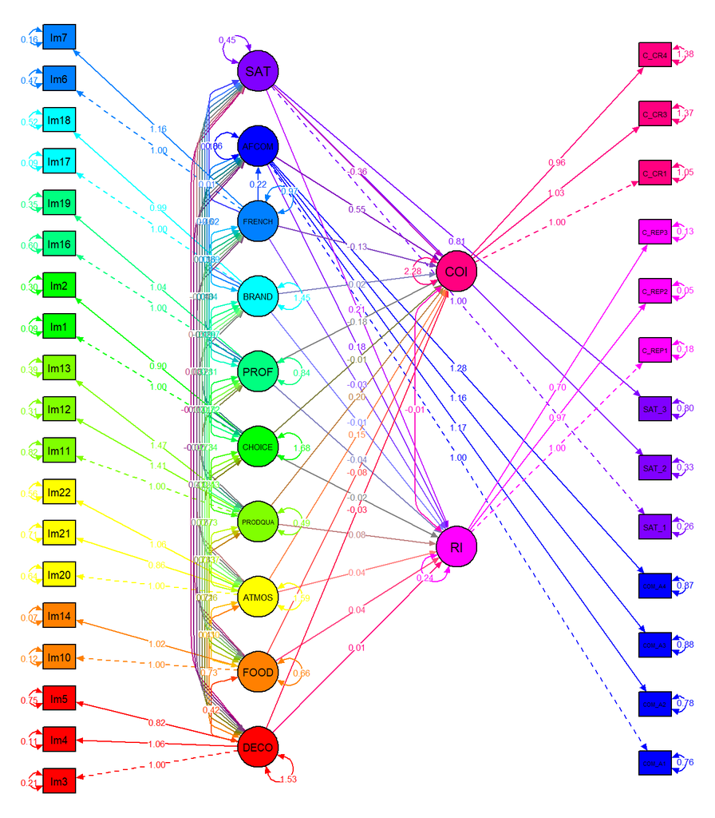

```r
semPaths(fit_SEM, what = "col", whatLabels = "par", style = "ram",
         rotation = 2, layout = "tree3",
         mar = c(1, 2, 1, 2), #margins
         nCharNodes = 7,
         shapeMan = "rectangle", # variable shape
         sizeMan = 4, # variable shape size
         sizeMan2 = 3, # variable shape vertical stretch
         # structural = T, # don't plot image variables (manifests)
         sizeInt = 1, # intercept size
         intercepts = F, # don't include intercepts
         sizeLat = 5, #factor size
         asize = 2, # arrow size
         curvePivot=T, # edge broken curve
         edge.label.cex = .5, # edge label size
         # edge.color = "skyblue4",
         # levels= c(1,2,7,8,9,10),
         groups = "latents",
         cut = .5 #cutoff for edges,
         )
```

Let us now assess this model

### Global fit measures

```r
global_fit_measures <- f_global_fit_measures(fit_SEM)
# check global fit pass/fail of global fit measures
global_fit_measures[[1]]
```

Value

Result

pvalue

0.000

FAIL

chisq

700.455

cfi

0.974

Accept model

rmsea

0.037

Good fit

### Regression results and full summary

```r
# output full summary
global_fit_measures[[2]]
```

```
## lavaan 0.6.15 ended normally after 150 iterations
##
##   Estimator                                         ML
##   Optimization method                           NLMINB
##   Number of model parameters                       161
##
##   Number of observations                           553
##   Number of missing patterns                       135
##
## Model Test User Model:
##
##   Test statistic                               700.455
##   Degrees of freedom                               399
##   P-value (Chi-square)                           0.000
##
## Model Test Baseline Model:
##
##   Test statistic                             11978.557
##   Degrees of freedom                               496
##   P-value                                        0.000
##
## User Model versus Baseline Model:
##
##   Comparative Fit Index (CFI)                    0.974
##   Tucker-Lewis Index (TLI)                       0.967
##
##   Robust Comparative Fit Index (CFI)             0.974
##   Robust Tucker-Lewis Index (TLI)                0.968
##
## Loglikelihood and Information Criteria:
##
##   Loglikelihood user model (H0)             -22368.900
##   Loglikelihood unrestricted model (H1)     -22018.673
##
##   Akaike (AIC)                               45059.800
##   Bayesian (BIC)                             45754.573
##   Sample-size adjusted Bayesian (SABIC)      45243.488
##
## Root Mean Square Error of Approximation:
##
```

[output cut: 281 more lines]

```
##     caa6              0.087    0.060    1.464    0.143    0.048    0.048
##     PROFtoRI_total    0.091    0.058    1.563    0.118    0.141    0.141
##     PROFtoCOI_totl   -0.253    0.172   -1.470    0.142   -0.140   -0.140
##     rss7              0.002    0.010    0.178    0.859    0.003    0.003
##     raa7             -0.003    0.011   -0.304    0.761   -0.007   -0.007
##     css7             -0.003    0.016   -0.177    0.859   -0.002   -0.002
##     caa7             -0.010    0.032   -0.304    0.761   -0.007   -0.007
##     BRANDtoRI_totl   -0.012    0.032   -0.383    0.702   -0.025   -0.025
##     BRANDtoCOI_ttl    0.010    0.096    0.101    0.919    0.007    0.007
##     rss8              0.022    0.011    1.928    0.054    0.037    0.037
##     raa8              0.041    0.013    3.043    0.002    0.068    0.068
##     css8             -0.037    0.022   -1.669    0.095   -0.022   -0.022
##     caa8              0.122    0.040    3.027    0.002    0.072    0.072
##     FRENCHtoRI_ttl    0.029    0.035    0.835    0.404    0.049    0.049
##     FRENCHtCOI_ttl   -0.042    0.106   -0.395    0.693   -0.025   -0.025
```

### local fit measures

```r
lambda = inspect(fit_SEM, what="std")$lambda
theta = inspect(fit_SEM, what="std")$theta
psi = inspect(fit_SEM, what="std")$psi
```

#### Indicator reliability criterion (Individual Item Reliability)

```r
# calculate indicator reliabilities (should be larger than 0.4)
indic_rel <- f_indic_rel(lambda, theta)
# pass/fail
indic_rel[[1]]
```

|  | Result |
| --- | --- |
| Individual Item Reliability | Fail |

```r
# details
indic_rel[[2]]
```

```
##         DECO  FOOD ATMOS PRODQU CHOICE  PROF BRAND FRENCH AFCOM   SAT    RI
## Im3    0.877   NaN   NaN    NaN    NaN   NaN   NaN    NaN   NaN   NaN   NaN
## Im4    0.940   NaN   NaN    NaN    NaN   NaN   NaN    NaN   NaN   NaN   NaN
## Im5    0.578   NaN   NaN    NaN    NaN   NaN   NaN    NaN   NaN   NaN   NaN
## Im10     NaN 0.847   NaN    NaN    NaN   NaN   NaN    NaN   NaN   NaN   NaN
## Im14     NaN 0.912   NaN    NaN    NaN   NaN   NaN    NaN   NaN   NaN   NaN
## Im20     NaN   NaN 0.712    NaN    NaN   NaN   NaN    NaN   NaN   NaN   NaN
## Im21     NaN   NaN 0.623    NaN    NaN   NaN   NaN    NaN   NaN   NaN   NaN
## Im22     NaN   NaN 0.761    NaN    NaN   NaN   NaN    NaN   NaN   NaN   NaN
## Im11     NaN   NaN   NaN  0.375    NaN   NaN   NaN    NaN   NaN   NaN   NaN
## Im12     NaN   NaN   NaN  0.760    NaN   NaN   NaN    NaN   NaN   NaN   NaN
## Im13     NaN   NaN   NaN  0.731    NaN   NaN   NaN    NaN   NaN   NaN   NaN
## Im1      NaN   NaN   NaN    NaN  0.949   NaN   NaN    NaN   NaN   NaN   NaN
## Im2      NaN   NaN   NaN    NaN  0.817   NaN   NaN    NaN   NaN   NaN   NaN
## Im16     NaN   NaN   NaN    NaN    NaN 0.584   NaN    NaN   NaN   NaN   NaN
## Im19     NaN   NaN   NaN    NaN    NaN 0.727   NaN    NaN   NaN   NaN   NaN
## Im17     NaN   NaN   NaN    NaN    NaN   NaN 0.940    NaN   NaN   NaN   NaN
## Im18     NaN   NaN   NaN    NaN    NaN   NaN 0.732    NaN   NaN   NaN   NaN
## Im6      NaN   NaN   NaN    NaN    NaN   NaN   NaN  0.676   NaN   NaN   NaN
## Im7      NaN   NaN   NaN    NaN    NaN   NaN   NaN  0.892   NaN   NaN   NaN
## COM_A1   NaN   NaN   NaN    NaN    NaN   NaN   NaN    NaN 0.634   NaN   NaN
## COM_A2   NaN   NaN   NaN    NaN    NaN   NaN   NaN    NaN 0.698   NaN   NaN
## COM_A3   NaN   NaN   NaN    NaN    NaN   NaN   NaN    NaN 0.667   NaN   NaN
## COM_A4   NaN   NaN   NaN    NaN    NaN   NaN   NaN    NaN 0.710   NaN   NaN
## SAT_1    NaN   NaN   NaN    NaN    NaN   NaN   NaN    NaN   NaN 0.748   NaN
## SAT_2    NaN   NaN   NaN    NaN    NaN   NaN   NaN    NaN   NaN 0.671   NaN
## SAT_3    NaN   NaN   NaN    NaN    NaN   NaN   NaN    NaN   NaN 0.390   NaN
## C_REP1   NaN   NaN   NaN    NaN    NaN   NaN   NaN    NaN   NaN   NaN 0.666
## C_REP2   NaN   NaN   NaN    NaN    NaN   NaN   NaN    NaN   NaN   NaN 0.867
## C_REP3   NaN   NaN   NaN    NaN    NaN   NaN   NaN    NaN   NaN   NaN 0.572
## C_CR1    NaN   NaN   NaN    NaN    NaN   NaN   NaN    NaN   NaN   NaN   NaN
## C_CR3    NaN   NaN   NaN    NaN    NaN   NaN   NaN    NaN   NaN   NaN   NaN
## C_CR4    NaN   NaN   NaN    NaN    NaN   NaN   NaN    NaN   NaN   NaN   NaN
##          COI
## Im3      NaN
## Im4      NaN
## Im5      NaN
## Im10     NaN
## Im14     NaN
## Im20     NaN
```

[output cut: 11 more lines]

```
## Im6      NaN
## Im7      NaN
## COM_A1   NaN
## COM_A2   NaN
## COM_A3   NaN
## COM_A4   NaN
## SAT_1    NaN
## SAT_2    NaN
## SAT_3    NaN
## C_REP1   NaN
## C_REP2   NaN
## C_REP3   NaN
## C_CR1  0.724
## C_CR3  0.682
## C_CR4  0.649
```

#### Construct reliability criterion

```r
# calculate construct reliability (should be above .6)
construct_rel <- f_construct_rel(lambda,theta)
# pass/fail
construct_rel[[1]]
```

|  | Result |
| --- | --- |
| Construct Reliability | Pass |

```r
# details
construct_rel[[2]]
```

```
##               DECO      FOOD     ATMOS  PRODQUAL    CHOICE      PROF     BRAND
## DECO     0.9215576       NaN       NaN       NaN       NaN       NaN       NaN
## FOOD           NaN 0.9360531       NaN       NaN       NaN       NaN       NaN
## ATMOS          NaN       NaN 0.8740997       NaN       NaN       NaN       NaN
## PRODQUAL       NaN       NaN       NaN 0.8285131       NaN       NaN       NaN
## CHOICE         NaN       NaN       NaN       NaN 0.9379212       NaN       NaN
## PROF           NaN       NaN       NaN       NaN       NaN 0.7914389       NaN
## BRAND          NaN       NaN       NaN       NaN       NaN       NaN 0.9103502
## FRENCH         NaN       NaN       NaN       NaN       NaN       NaN       NaN
## AFCOM          NaN       NaN       NaN       NaN       NaN       NaN       NaN
## SAT            NaN       NaN       NaN       NaN       NaN       NaN       NaN
## RI             NaN       NaN       NaN       NaN       NaN       NaN       NaN
## COI            NaN       NaN       NaN       NaN       NaN       NaN       NaN
##             FRENCH     AFCOM       SAT        RI       COI
## DECO           NaN       NaN       NaN       NaN       NaN
## FOOD           NaN       NaN       NaN       NaN       NaN
## ATMOS          NaN       NaN       NaN       NaN       NaN
## PRODQUAL       NaN       NaN       NaN       NaN       NaN
## CHOICE         NaN       NaN       NaN       NaN       NaN
## PROF           NaN       NaN       NaN       NaN       NaN
## BRAND          NaN       NaN       NaN       NaN       NaN
## FRENCH   0.8785003       NaN       NaN       NaN       NaN
## AFCOM          NaN 0.8934602       NaN       NaN       NaN
## SAT            NaN       NaN 0.8173149       NaN       NaN
## RI             NaN       NaN       NaN 0.8749194       NaN
## COI            NaN       NaN       NaN       NaN 0.8670792
```

#### Average Variance Extracted criterion

```r
# calculate Average Variance Extracted (should be above .5)
AVE <- f_AVE(lambda,theta)
# pass/fail
AVE[[1]]
```

|  | Result |
| --- | --- |
| Average Variance Extracted | Pass |

```r
# details
diag(AVE[[2]])
```

```
##      DECO      FOOD     ATMOS  PRODQUAL    CHOICE      PROF     BRAND    FRENCH
## 0.7983093 0.8798287 0.6986336 0.6223004 0.8832435 0.6555349 0.8359891 0.7841305
##     AFCOM       SAT        RI       COI
## 0.6771639 0.6029676 0.7014342 0.6850899
```

#### Construct correlations

```r
# correlations between constructs (factors...) should be lower than .7
construct_cor <- f_construct_corr(psi)
# pass / fail
construct_cor[[1]]
```

|  | Result |
| --- | --- |
| Construct Correlations | Pass |

```r
# details
construct_cor[[2]]
```

```
##            DECO   FOOD  ATMOS PRODQU CHOICE   PROF  BRAND FRENCH  AFCOM    SAT
## DECO      1.000
## FOOD      0.417  1.000
## ATMOS     0.467  0.295  1.000
## PRODQUAL  0.470  0.452  0.418  1.000
## CHOICE    0.442  0.312  0.447  0.477  1.000
## PROF      0.655  0.499  0.476  0.531  0.602  1.000
## BRAND     0.516  0.325  0.516  0.565  0.521  0.602  1.000
## FRENCH    0.339  0.587  0.333  0.305  0.228  0.370  0.327  1.000
## AFCOM     0.000  0.000  0.000  0.000  0.000  0.000  0.000  0.000  0.659
## SAT       0.000  0.000  0.000  0.000  0.000  0.000  0.000  0.000  0.000  0.576
## RI        0.000  0.000  0.000  0.000  0.000  0.000  0.000  0.000  0.000  0.000
## COI       0.000  0.000  0.000  0.000  0.000  0.000  0.000  0.000  0.000  0.000
##              RI    COI
## DECO
## FOOD
## ATMOS
## PRODQUAL
## CHOICE
## PROF
## BRAND
## FRENCH
## AFCOM
## SAT
## RI        0.667
## COI      -0.020  0.829
```

#### Fornell-Larcker Criteria

```r
# AVE should be higher than squared correlations between constructs
fornell_larcker <- f_fornell_larcker(psi,AVE[[2]])
# pass / fail
fornell_larcker[[1]]
```

|  | Result |
| --- | --- |
| Fornell-Larcker Criteria | Pass |

```r
# details (note: AVE is in the diagonals)
fornell_larcker[[2]]
```

```
##           DECO  FOOD ATMOS PRODQU CHOICE  PROF BRAND FRENCH AFCOM   SAT    RI
## DECO     0.798
## FOOD     0.174 0.880
## ATMOS    0.218 0.087 0.699
## PRODQUAL 0.221 0.204 0.175  0.622
## CHOICE   0.195 0.097 0.200  0.228  0.883
## PROF     0.429 0.249 0.227  0.282  0.362 0.656
## BRAND    0.266 0.106 0.266  0.319  0.271 0.362 0.836
## FRENCH   0.115 0.345 0.111  0.093  0.052 0.137 0.107  0.784
## AFCOM    0.000 0.000 0.000  0.000  0.000 0.000 0.000  0.000 0.677
## SAT      0.000 0.000 0.000  0.000  0.000 0.000 0.000  0.000 0.000 0.603
## RI       0.000 0.000 0.000  0.000  0.000 0.000 0.000  0.000 0.000 0.000 0.701
## COI      0.000 0.000 0.000  0.000  0.000 0.000 0.000  0.000 0.000 0.000 0.000
##            COI
## DECO
## FOOD
## ATMOS
## PRODQUAL
## CHOICE
## PROF
## BRAND
## FRENCH
## AFCOM
## SAT
## RI
## COI      0.685
```

### Modification indices

```r
arrange(modificationindices(fit_SEM),-mi) |> filter(mi>10)
```

```
##         lhs op    rhs     mi    epc sepc.lv sepc.all sepc.nox
## 1     AFCOM =~ C_REP1 56.860  0.174   0.199    0.272    0.272
## 2    C_REP2 ~~ C_REP3 53.856  0.103   0.103    1.250    1.250
## 3      Im10 ~~   Im14 37.563 98.286  98.286 1115.792 1115.792
## 4       Im6 ~~    Im7 37.385 10.888  10.888   40.087   40.087
## 5       SAT  ~    COI 37.385  0.457   0.859    0.859    0.859
## 6     AFCOM  ~    COI 37.384 -1.343  -1.946   -1.946   -1.946
## 7     AFCOM  ~    SAT 37.384  0.480   0.370    0.370    0.370
## 8       SAT  ~  AFCOM 37.384  0.250   0.324    0.324    0.324
## 9     AFCOM ~~    SAT 37.384  0.215   0.346    0.346    0.346
## 10    AFCOM  ~     RI 37.384  2.236   1.166    1.166    1.166
## 11      SAT  ~     RI 37.384  1.354   0.915    0.915    0.915
## 12     Im16 ~~   Im19 37.375  3.054   3.054    6.702    6.702
## 13      Im1 ~~    Im2 37.374 14.223  14.223   86.296   86.296
## 14   COM_A1 ~~ COM_A2 24.605  0.250   0.250    0.326    0.326
```

[output cut: 23 more lines]

### Discussion

This model is much better and is satisfactory as we can see from the fit assessments above.

Looking at the modification indices we see that variable C_REP1 wants to link up with AFCOM, but changing this configuration makes the model perform much worse.

Finally we check if we can improve the model by adding some correlations between the mediators and the outcome dimensions. This makes sense as we would expect *Customer Satisfaction* and *Affective commitment* to be correlated and *Repurchase Intention* and *Cocreation intention* to also be correlated to each other.

## ROUND 4

### Model

```r
# Im8, Im9, Im15 are excluded
# we have allowed correlation between SAT and AFCOM and also between RI and COI
model_SEM <- "
DECO =~ Im3 + Im4 + Im5
FOOD =~ Im10 + Im14
ATMOS =~ Im20 + Im21 + Im22
PRODQUAL =~ Im11 + Im12 + Im13
CHOICE =~ Im1 + Im2
PROF =~ Im16 + Im19
BRAND =~ Im17 + Im18
FRENCH =~ Im6 + Im7

AFCOM =~ COM_A1 + COM_A2 + COM_A3 + COM_A4
SAT =~ SAT_1 + SAT_2 + SAT_3
RI =~ C_REP1 + C_REP2 + C_REP3
COI =~ C_CR1 + C_CR2 + C_CR3 + C_CR4

SAT ~ s1*DECO + s2*FOOD + s3*ATMOS + s4*PRODQUAL + s5*CHOICE + s6*PROF + s7*BRAND + s8*FRENCH
AFCOM ~ a1*DECO + a2*FOOD + a3*ATMOS + a4*PRODQUAL + a5*CHOICE + a6*PROF + a7*BRAND + a8*FRENCH
SAT ~~ AFCOM

RI ~ rs*SAT + ra*AFCOM + r01*DECO + r02*FOOD + r03*ATMOS + r04*PRODQUAL + r05*CHOICE + r06*PROF + r07*BRAND + r08*FRENCH
COI ~ cs*SAT + ca*AFCOM + c01*DECO + c02*FOOD + c03*ATMOS + c04*PRODQUAL + c05*CHOICE + c06*PROF + c07*BRAND + c08*FRENCH
RI ~~ COI

rss1:= rs*s1
raa1:= ra*a1
css1:= cs*s1
caa1:= ca*a1
DECOtoRI:= r01 + rss1 + raa1
DECOtoCOI:= c01 + css1 + caa1

rss2:= rs*s2
raa2:= ra*a2
css2:= cs*s2
caa2:= ca*a2
FOODtoRI_total:= r02 + rss2 + raa2
FOODtoCOI_total:= c02 + css2 + caa2

rss3:= rs*s3
raa3:= ra*a3
css3:= cs*s3
caa3:= ca*a3
ATMOStoRI_total:= r03 + rss3 + raa3
ATMOStoCOI_total:= c03 + css3 + caa3

rss4:= rs*s4
raa4:= ra*a4
css4:= cs*s4
caa4:= ca*a4
PQUALtoRI_total:= r04 + rss4 + raa4
PQUALtoCOI_total:= c04 + css4 + caa4

rss5:= rs*s5
raa5:= ra*a5
css5:= cs*s5
caa5:= ca*a5
CHOICEtoRI_total:= r05 + rss5 + raa5
CHOICEtoCOI_total:= c05 + css5 + caa5

rss6:= rs*s6
raa6:= ra*a6
css6:= cs*s6
caa6:= ca*a6
PROFtoRI_total:= r06 + rss6 + raa6
PROFtoCOI_total:= c06 + css6 + caa6

rss7:= rs*s7
raa7:= ra*a7
css7:= cs*s7
caa7:= ca*a7
BRANDtoRI_total:= r07 + rss7 + raa7
BRANDtoCOI_total:= c07 + css7 + caa7

rss8:= rs*s8
raa8:= ra*a8
css8:= cs*s8
caa8:= ca*a8
FRENCHtoRI_total:= r08 + rss8 + raa8
FRENCHtoCOI_total:= c08 + css8 + caa8
"
```

### Fit

```r
fit_SEM <- cfa(model_SEM, data=survey, missing="ML")
```

### SEM plot

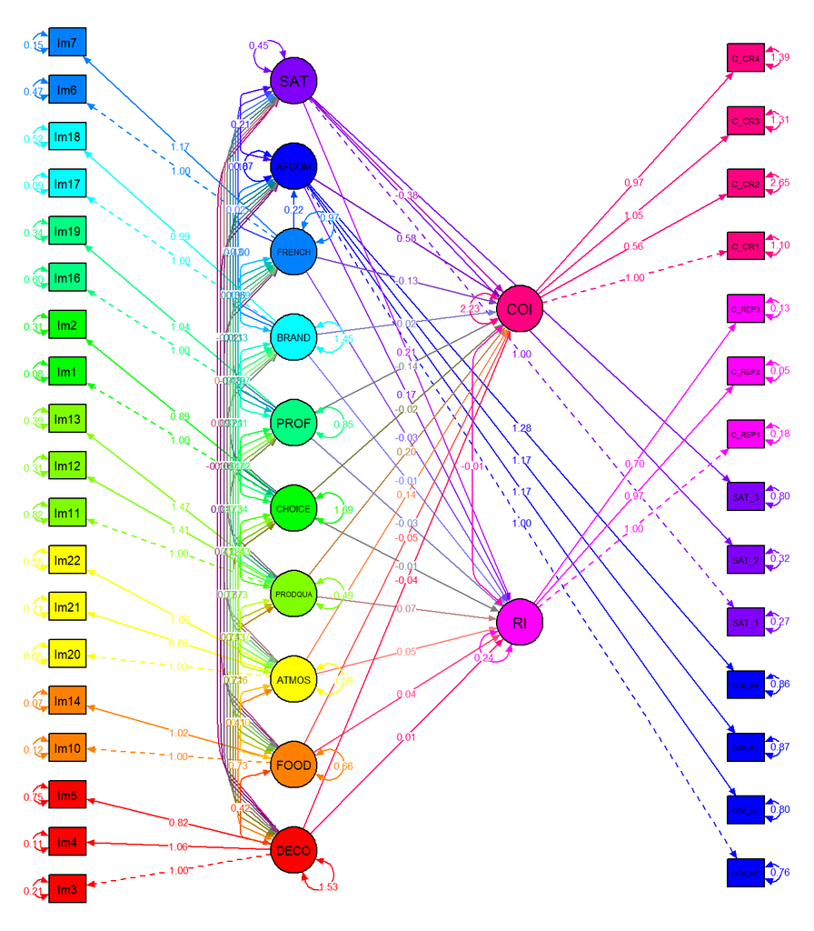

```r
semPaths(fit_SEM, what = "col", whatLabels = "par", style = "ram",
         rotation = 2, layout = "tree3",
         mar = c(1, 2, 1, 2), #margins
         nCharNodes = 7,
         shapeMan = "rectangle", # variable shape
         sizeMan = 4, # variable shape size
         sizeMan2 = 3, # variable shape vertical stretch
         # structural = T, # don't plot image variables (manifests)
         sizeInt = 1, # intercept size
         intercepts = F, # don't include intercepts
         sizeLat = 5, #factor size
         asize = 2, # arrow size
         curvePivot=T, # edge broken curve
         edge.label.cex = .5, # edge label size
         # edge.color = "skyblue4",
         # levels= c(1,2,7,8,9,10),
         groups = "latents",
         cut = .5 #cutoff for edges,
         )
```

Let us now assess this model

### Global fit measures

```r
global_fit_measures <- f_global_fit_measures(fit_SEM)
# check global fit pass/fail of global fit measures
global_fit_measures[[1]]
```

Value

Result

pvalue

0.000

FAIL

chisq

711.708

cfi

0.976

Accept model

rmsea

0.035

Good fit

### Regression results and full summary

```r
# output full summary
global_fit_measures[[2]]
```

```
## lavaan 0.6.15 ended normally after 144 iterations
##
##   Estimator                                         ML
##   Optimization method                           NLMINB
##   Number of model parameters                       165
##
##   Number of observations                           553
##   Number of missing patterns                       144
##
## Model Test User Model:
##
##   Test statistic                               711.708
##   Degrees of freedom                               429
##   P-value (Chi-square)                           0.000
##
## Model Test Baseline Model:
##
##   Test statistic                             12148.481
##   Degrees of freedom                               528
##   P-value                                        0.000
##
## User Model versus Baseline Model:
##
##   Comparative Fit Index (CFI)                    0.976
##   Tucker-Lewis Index (TLI)                       0.970
##
##   Robust Comparative Fit Index (CFI)             0.976
##   Robust Tucker-Lewis Index (TLI)                0.970
##
## Loglikelihood and Information Criteria:
##
##   Loglikelihood user model (H0)             -23357.440
##   Loglikelihood unrestricted model (H1)     -23001.586
##
##   Akaike (AIC)                               47044.880
##   Bayesian (BIC)                             47756.914
##   Sample-size adjusted Bayesian (SABIC)      47233.130
##
## Root Mean Square Error of Approximation:
##
```

[output cut: 286 more lines]

```
##     caa6              0.034    0.058    0.582    0.560    0.019    0.019
##     PROFtoRI_total    0.071    0.058    1.229    0.219    0.108    0.108
##     PROFtoCOI_totl   -0.271    0.168   -1.614    0.106   -0.154   -0.154
##     rss7              0.003    0.009    0.346    0.729    0.006    0.006
##     raa7             -0.000    0.010   -0.017    0.987   -0.000   -0.000
##     css7             -0.006    0.017   -0.345    0.730   -0.004   -0.004
##     caa7             -0.001    0.033   -0.017    0.987   -0.000   -0.000
##     BRANDtoRI_totl   -0.008    0.033   -0.255    0.799   -0.017   -0.017
##     BRANDtoCOI_ttl    0.014    0.094    0.147    0.883    0.010    0.010
##     rss8              0.020    0.011    1.824    0.068    0.033    0.033
##     raa8              0.038    0.013    2.922    0.003    0.061    0.061
##     css8             -0.037    0.023   -1.624    0.104   -0.022   -0.022
##     caa8              0.126    0.042    2.999    0.003    0.076    0.076
##     FRENCHtoRI_ttl    0.028    0.036    0.775    0.438    0.045    0.045
##     FRENCHtCOI_ttl   -0.042    0.104   -0.406    0.685   -0.026   -0.026
```

### local fit measures

```r
lambda = inspect(fit_SEM, what="std")$lambda
theta = inspect(fit_SEM, what="std")$theta
psi = inspect(fit_SEM, what="std")$psi
```

#### Indicator reliability criterion (Individual Item Reliability)

```r
# calculate indicator reliabilities (should be larger than 0.4)
indic_rel <- f_indic_rel(lambda, theta)
# pass/fail
indic_rel[[1]]
```

|  | Result |
| --- | --- |
| Individual Item Reliability | Fail |

```r
# details
indic_rel[[2]]
```

```
##         DECO  FOOD ATMOS PRODQU CHOICE  PROF BRAND FRENCH AFCOM   SAT    RI
## Im3    0.877   NaN   NaN    NaN    NaN   NaN   NaN    NaN   NaN   NaN   NaN
## Im4    0.941   NaN   NaN    NaN    NaN   NaN   NaN    NaN   NaN   NaN   NaN
## Im5    0.578   NaN   NaN    NaN    NaN   NaN   NaN    NaN   NaN   NaN   NaN
## Im10     NaN 0.848   NaN    NaN    NaN   NaN   NaN    NaN   NaN   NaN   NaN
## Im14     NaN 0.912   NaN    NaN    NaN   NaN   NaN    NaN   NaN   NaN   NaN
## Im20     NaN   NaN 0.711    NaN    NaN   NaN   NaN    NaN   NaN   NaN   NaN
## Im21     NaN   NaN 0.621    NaN    NaN   NaN   NaN    NaN   NaN   NaN   NaN
## Im22     NaN   NaN 0.764    NaN    NaN   NaN   NaN    NaN   NaN   NaN   NaN
## Im11     NaN   NaN   NaN  0.375    NaN   NaN   NaN    NaN   NaN   NaN   NaN
## Im12     NaN   NaN   NaN  0.759    NaN   NaN   NaN    NaN   NaN   NaN   NaN
## Im13     NaN   NaN   NaN  0.732    NaN   NaN   NaN    NaN   NaN   NaN   NaN
## Im1      NaN   NaN   NaN    NaN  0.954   NaN   NaN    NaN   NaN   NaN   NaN
## Im2      NaN   NaN   NaN    NaN  0.814   NaN   NaN    NaN   NaN   NaN   NaN
## Im16     NaN   NaN   NaN    NaN    NaN 0.589   NaN    NaN   NaN   NaN   NaN
## Im19     NaN   NaN   NaN    NaN    NaN 0.730   NaN    NaN   NaN   NaN   NaN
## Im17     NaN   NaN   NaN    NaN    NaN   NaN 0.940    NaN   NaN   NaN   NaN
## Im18     NaN   NaN   NaN    NaN    NaN   NaN 0.732    NaN   NaN   NaN   NaN
## Im6      NaN   NaN   NaN    NaN    NaN   NaN   NaN  0.672   NaN   NaN   NaN
## Im7      NaN   NaN   NaN    NaN    NaN   NaN   NaN  0.899   NaN   NaN   NaN
## COM_A1   NaN   NaN   NaN    NaN    NaN   NaN   NaN    NaN 0.632   NaN   NaN
## COM_A2   NaN   NaN   NaN    NaN    NaN   NaN   NaN    NaN 0.689   NaN   NaN
## COM_A3   NaN   NaN   NaN    NaN    NaN   NaN   NaN    NaN 0.672   NaN   NaN
## COM_A4   NaN   NaN   NaN    NaN    NaN   NaN   NaN    NaN 0.714   NaN   NaN
## SAT_1    NaN   NaN   NaN    NaN    NaN   NaN   NaN    NaN   NaN 0.736   NaN
## SAT_2    NaN   NaN   NaN    NaN    NaN   NaN   NaN    NaN   NaN 0.681   NaN
## SAT_3    NaN   NaN   NaN    NaN    NaN   NaN   NaN    NaN   NaN 0.390   NaN
## C_REP1   NaN   NaN   NaN    NaN    NaN   NaN   NaN    NaN   NaN   NaN 0.672
## C_REP2   NaN   NaN   NaN    NaN    NaN   NaN   NaN    NaN   NaN   NaN 0.870
## C_REP3   NaN   NaN   NaN    NaN    NaN   NaN   NaN    NaN   NaN   NaN 0.578
## C_CR1    NaN   NaN   NaN    NaN    NaN   NaN   NaN    NaN   NaN   NaN   NaN
## C_CR2    NaN   NaN   NaN    NaN    NaN   NaN   NaN    NaN   NaN   NaN   NaN
## C_CR3    NaN   NaN   NaN    NaN    NaN   NaN   NaN    NaN   NaN   NaN   NaN
## C_CR4    NaN   NaN   NaN    NaN    NaN   NaN   NaN    NaN   NaN   NaN   NaN
##          COI
## Im3      NaN
## Im4      NaN
## Im5      NaN
## Im10     NaN
## Im14     NaN
```

[output cut: 13 more lines]

```
## Im7      NaN
## COM_A1   NaN
## COM_A2   NaN
## COM_A3   NaN
## COM_A4   NaN
## SAT_1    NaN
## SAT_2    NaN
## SAT_3    NaN
## C_REP1   NaN
## C_REP2   NaN
## C_REP3   NaN
## C_CR1  0.707
## C_CR2  0.238
## C_CR3  0.691
## C_CR4  0.643
```

#### Construct reliability criterion

```r
# calculate construct reliability (should be above .6)
construct_rel <- f_construct_rel(lambda,theta)
# pass/fail
construct_rel[[1]]
```

|  | Result |
| --- | --- |
| Construct Reliability | Pass |

```r
# details
construct_rel[[2]]
```

```
##              DECO      FOOD     ATMOS  PRODQUAL    CHOICE     PROF     BRAND
## DECO     0.921565       NaN       NaN       NaN       NaN      NaN       NaN
## FOOD          NaN 0.9360468       NaN       NaN       NaN      NaN       NaN
## ATMOS         NaN       NaN 0.8742497       NaN       NaN      NaN       NaN
## PRODQUAL      NaN       NaN       NaN 0.8285011       NaN      NaN       NaN
## CHOICE        NaN       NaN       NaN       NaN 0.9381434      NaN       NaN
## PROF          NaN       NaN       NaN       NaN       NaN 0.794116       NaN
## BRAND         NaN       NaN       NaN       NaN       NaN      NaN 0.9103408
## FRENCH        NaN       NaN       NaN       NaN       NaN      NaN       NaN
## AFCOM         NaN       NaN       NaN       NaN       NaN      NaN       NaN
## SAT           NaN       NaN       NaN       NaN       NaN      NaN       NaN
## RI            NaN       NaN       NaN       NaN       NaN      NaN       NaN
## COI           NaN       NaN       NaN       NaN       NaN      NaN       NaN
##            FRENCH     AFCOM       SAT        RI       COI
## DECO          NaN       NaN       NaN       NaN       NaN
## FOOD          NaN       NaN       NaN       NaN       NaN
## ATMOS         NaN       NaN       NaN       NaN       NaN
## PRODQUAL      NaN       NaN       NaN       NaN       NaN
## CHOICE        NaN       NaN       NaN       NaN       NaN
## PROF          NaN       NaN       NaN       NaN       NaN
## BRAND         NaN       NaN       NaN       NaN       NaN
## FRENCH   0.879139       NaN       NaN       NaN       NaN
## AFCOM         NaN 0.8932691       NaN       NaN       NaN
## SAT           NaN       NaN 0.8169018       NaN       NaN
## RI            NaN       NaN       NaN 0.8776213       NaN
## COI           NaN       NaN       NaN       NaN 0.8359885
```

#### Average Variance Extracted criterion

```r
# calculate Average Variance Extracted (should be above .5)
AVE <- f_AVE(lambda,theta)
# pass/fail
AVE[[1]]
```

|  | Result |
| --- | --- |
| Average Variance Extracted | Pass |

```r
# details
diag(AVE[[2]])
```

```
##      DECO      FOOD     ATMOS  PRODQUAL    CHOICE      PROF     BRAND    FRENCH
## 0.7983252 0.8798167 0.6989401 0.6222781 0.8836552 0.6591798 0.8359726 0.7852351
##     AFCOM       SAT        RI       COI
## 0.6767297 0.6022343 0.7065603 0.5697335
```

#### Construct correlations

```r
# correlations between constructs (factors...) should be lower than .7
construct_cor <- f_construct_corr(psi)
# pass / fail
construct_cor[[1]]
```

|  | Result |
| --- | --- |
| Construct Correlations | Pass |

```r
# details
construct_cor[[2]]
```

```
##            DECO   FOOD  ATMOS PRODQU CHOICE   PROF  BRAND FRENCH  AFCOM    SAT
## DECO      1.000
## FOOD      0.417  1.000
## ATMOS     0.467  0.295  1.000
## PRODQUAL  0.470  0.452  0.418  1.000
## CHOICE    0.441  0.311  0.448  0.477  1.000
## PROF      0.653  0.498  0.477  0.529  0.599  1.000
## BRAND     0.516  0.325  0.516  0.565  0.520  0.600  1.000
## FRENCH    0.337  0.586  0.333  0.305  0.227  0.369  0.325  1.000
## AFCOM     0.000  0.000  0.000  0.000  0.000  0.000  0.000  0.000  0.669
## SAT       0.000  0.000  0.000  0.000  0.000  0.000  0.000  0.000  0.342  0.587
## RI        0.000  0.000  0.000  0.000  0.000  0.000  0.000  0.000  0.000  0.000
## COI       0.000  0.000  0.000  0.000  0.000  0.000  0.000  0.000  0.000  0.000
##              RI    COI
## DECO
## FOOD
## ATMOS
## PRODQUAL
## CHOICE
## PROF
## BRAND
## FRENCH
## AFCOM
## SAT
## RI        0.649
## COI      -0.008  0.842
```

#### Fornell-Larcker Criteria

```r
# AVE should be higher than squared correlations between constructs
fornell_larcker <- f_fornell_larcker(psi,AVE[[2]])
# pass / fail
fornell_larcker[[1]]
```

|  | Result |
| --- | --- |
| Fornell-Larcker Criteria | Pass |

```r
# details (note: AVE is in the diagonals)
fornell_larcker[[2]]
```

```
##           DECO  FOOD ATMOS PRODQU CHOICE  PROF BRAND FRENCH AFCOM   SAT    RI
## DECO     0.798
## FOOD     0.174 0.880
## ATMOS    0.218 0.087 0.699
## PRODQUAL 0.221 0.204 0.175  0.622
## CHOICE   0.195 0.097 0.200  0.228  0.884
## PROF     0.427 0.248 0.228  0.280  0.359 0.659
## BRAND    0.266 0.106 0.266  0.320  0.270 0.361 0.836
## FRENCH   0.114 0.344 0.111  0.093  0.052 0.136 0.106  0.785
## AFCOM    0.000 0.000 0.000  0.000  0.000 0.000 0.000  0.000 0.677
## SAT      0.000 0.000 0.000  0.000  0.000 0.000 0.000  0.000 0.117 0.602
## RI       0.000 0.000 0.000  0.000  0.000 0.000 0.000  0.000 0.000 0.000 0.707
## COI      0.000 0.000 0.000  0.000  0.000 0.000 0.000  0.000 0.000 0.000 0.000
##            COI
## DECO
## FOOD
## ATMOS
## PRODQUAL
## CHOICE
## PROF
## BRAND
## FRENCH
## AFCOM
## SAT
## RI
## COI      0.570
```

### Modification indices

```r
arrange(modificationindices(fit_SEM),-mi) |> filter(mi>10)
```

```
##       lhs op    rhs     mi    epc sepc.lv sepc.all sepc.nox
## 1   AFCOM =~ C_REP1 62.289  0.190   0.217    0.294    0.294
## 2  C_REP2 ~~ C_REP3 51.766  0.098   0.098    1.191    1.191
## 3  COM_A1 ~~ COM_A2 27.168  0.260   0.260    0.333    0.333
## 4   BRAND =~   Im13 23.384  0.216   0.261    0.217    0.217
## 5   ATMOS =~ C_REP1 21.217  0.089   0.112    0.152    0.152
## 6    Im11 ~~   Im13 20.467 -0.185  -0.185   -0.329   -0.329
## 7      RI =~  C_CR2 19.220  0.558   0.337    0.181    0.181
## 8   AFCOM =~ C_REP2 18.417 -0.090  -0.102   -0.163   -0.163
## 9  C_REP1 ~~ C_REP3 17.887 -0.054  -0.054   -0.356   -0.356
## 10  BRAND =~   Im12 17.211 -0.178  -0.214   -0.188   -0.188
## 11   Im21 ~~   Im22 14.847 -0.247  -0.247   -0.394   -0.394
## 12 CHOICE =~   Im20 14.223 -0.149  -0.193   -0.129   -0.129
## 13   Im11 ~~   Im12 14.028  0.147   0.147    0.292    0.292
## 14 CHOICE =~   Im13 13.642  0.132   0.172    0.143    0.143
## 15  AFCOM =~   Im11 13.258  0.142   0.163    0.142    0.142
## 16    SAT =~  C_CR2 12.991  0.323   0.283    0.152    0.152
## 17    SAT =~ COM_A2 12.958 -0.242  -0.212   -0.132   -0.132
## 18   FOOD =~   Im11 12.865  0.216   0.175    0.153    0.153
## 19 COM_A3 ~~ C_REP1 12.723  0.076   0.076    0.192    0.192
## 20  AFCOM =~ C_REP3 12.587 -0.069  -0.079   -0.141   -0.141
## 21    SAT =~ C_REP1 11.578  0.107   0.093    0.127    0.127
## 22   Im21 ~~ C_REP3 11.436  0.053   0.053    0.174    0.174
## 23  ATMOS =~   Im12 10.823 -0.113  -0.143   -0.126   -0.126
## 24 CHOICE =~   Im12 10.740 -0.112  -0.145   -0.128   -0.128
## 25   Im13 ~~    Im1 10.491  0.067   0.067    0.373    0.373
## 26 CHOICE =~ C_REP1 10.452  0.055   0.072    0.097    0.097
```

### Discussion

The correlation indeed improves the results and this model is the best we were able to produce.

## Path analysis

### All elements in the model in alphabetical order

For reference here are all the direct, indirect and total effects in our model in alphabetical order

```r
paramest <- parameterestimates(fit_SEM, boot.ci.type = "bca.simple", standardized = TRUE)

paramest |>
  arrange(label) |> filter(label!="") |>
  stable()
```

| lhs | op | rhs | label | est | se | z | pvalue | ci.lower | ci.upper | std.lv | std.all | std.nox |
| --- | --- | --- | --- | --- | --- | --- | --- | --- | --- | --- | --- | --- |
| ATMOStoCOI_total | := | c03+css3+caa3 | ATMOStoCOI_total | 0.34 | 0.08 | 4.15 | 0.00 | 0.18 | 0.50 | 0.26 | 0.26 | 0.26 |
| ATMOStoRI_total | := | r03+rss3+raa3 | ATMOStoRI_total | 0.12 | 0.03 | 4.12 | 0.00 | 0.06 | 0.17 | 0.24 | 0.24 | 0.24 |
| BRANDtoCOI_total | := | c07+css7+caa7 | BRANDtoCOI_total | 0.01 | 0.09 | 0.15 | 0.88 | -0.17 | 0.20 | 0.01 | 0.01 | 0.01 |
| BRANDtoRI_total | := | r07+rss7+raa7 | BRANDtoRI_total | -0.01 | 0.03 | -0.26 | 0.80 | -0.07 | 0.06 | -0.02 | -0.02 | -0.02 |
| CHOICEtoCOI_total | := | c05+css5+caa5 | CHOICEtoCOI_total | 0.00 | 0.08 | -0.05 | 0.96 | -0.16 | 0.15 | 0.00 | 0.00 | 0.00 |
| CHOICEtoRI_total | := | r05+rss5+raa5 | CHOICEtoRI_total | 0.03 | 0.03 | 1.21 | 0.22 | -0.02 | 0.09 | 0.07 | 0.07 | 0.07 |
| DECOtoCOI | := | c01+css1+caa1 | DECOtoCOI | 0.00 | 0.09 | -0.04 | 0.97 | -0.18 | 0.17 | 0.00 | 0.00 | 0.00 |
| DECOtoRI | := | r01+rss1+raa1 | DECOtoRI | -0.01 | 0.03 | -0.38 | 0.70 | -0.07 | 0.05 | -0.02 | -0.02 | -0.02 |
| FOODtoCOI_total | := | c02+css2+caa2 | FOODtoCOI_total | -0.06 | 0.14 | -0.43 | 0.67 | -0.33 | 0.21 | -0.03 | -0.03 | -0.03 |
| FOODtoRI_total | := | r02+rss2+raa2 | FOODtoRI_total | 0.07 | 0.05 | 1.37 | 0.17 | -0.03 | 0.16 | 0.09 | 0.09 | 0.09 |
| FRENCHtoCOI_total | := | c08+css8+caa8 | FRENCHtoCOI_total | -0.04 | 0.10 | -0.41 | 0.68 | -0.25 | 0.16 | -0.03 | -0.03 | -0.03 |
| FRENCHtoRI_total | := | r08+rss8+raa8 | FRENCHtoRI_total | 0.03 | 0.04 | 0.78 | 0.44 | -0.04 | 0.10 | 0.04 | 0.04 | 0.04 |
| PQUALtoCOI_total | := | c04+css4+caa4 | PQUALtoCOI_total | 0.11 | 0.16 | 0.67 | 0.50 | -0.21 | 0.42 | 0.05 | 0.05 | 0.05 |
| PQUALtoRI_total | := | r04+rss4+raa4 | PQUALtoRI_total | 0.04 | 0.06 | 0.70 | 0.48 | -0.07 | 0.15 | 0.04 | 0.04 | 0.04 |
| PROFtoCOI_total | := | c06+css6+caa6 | PROFtoCOI_total | -0.27 | 0.17 | -1.61 | 0.11 | -0.60 | 0.06 | -0.15 | -0.15 | -0.15 |
| PROFtoRI_total | := | r06+rss6+raa6 | PROFtoRI_total | 0.07 | 0.06 | 1.23 | 0.22 | -0.04 | 0.18 | 0.11 | 0.11 | 0.11 |
| AFCOM | ~ | DECO | a1 | 0.01 | 0.05 | 0.11 | 0.91 | -0.10 | 0.11 | 0.01 | 0.01 | 0.01 |
| AFCOM | ~ | FOOD | a2 | 0.05 | 0.08 | 0.59 | 0.55 | -0.11 | 0.21 | 0.03 | 0.03 | 0.03 |
| AFCOM | ~ | ATMOS | a3 | 0.37 | 0.05 | 7.21 | 0.00 | 0.27 | 0.47 | 0.41 | 0.41 | 0.41 |
| AFCOM | ~ | PRODQUAL | a4 | -0.18 | 0.10 | -1.79 | 0.07 | -0.37 | 0.02 | -0.11 | -0.11 | -0.11 |
| AFCOM | ~ | CHOICE | a5 | 0.11 | 0.05 | 2.31 | 0.02 | 0.02 | 0.21 | 0.13 | 0.13 | 0.13 |
| AFCOM | ~ | PROF | a6 | 0.06 | 0.10 | 0.59 | 0.56 | -0.14 | 0.26 | 0.05 | 0.05 | 0.05 |
| AFCOM | ~ | BRAND | a7 | 0.00 | 0.06 | -0.02 | 0.99 | -0.11 | 0.11 | 0.00 | 0.00 | 0.00 |
| AFCOM | ~ | FRENCH | a8 | 0.22 | 0.06 | 3.43 | 0.00 | 0.09 | 0.34 | 0.19 | 0.19 | 0.19 |
| COI | ~ | DECO | c01 | -0.04 | 0.09 | -0.50 | 0.61 | -0.22 | 0.13 | -0.03 | -0.03 | -0.03 |
| COI | ~ | FOOD | c02 | -0.05 | 0.13 | -0.41 | 0.68 | -0.31 | 0.21 | -0.03 | -0.03 | -0.03 |
| COI | ~ | ATMOS | c03 | 0.14 | 0.09 | 1.62 | 0.10 | -0.03 | 0.31 | 0.11 | 0.11 | 0.11 |
| COI | ~ | PRODQUAL | c04 | 0.20 | 0.16 | 1.29 | 0.20 | -0.11 | 0.51 | 0.09 | 0.09 | 0.09 |
| COI | ~ | CHOICE | c05 | -0.02 | 0.08 | -0.23 | 0.81 | -0.17 | 0.14 | -0.01 | -0.01 | -0.01 |
| COI | ~ | PROF | c06 | -0.14 | 0.18 | -0.78 | 0.44 | -0.49 | 0.21 | -0.08 | -0.08 | -0.08 |

[output cut: 54 more lines]

## QUESTION 2

### Direct effects

Below we list all significant (p-value < 0.05) direct effects in our model ordered by effect size for each endogenous variable.

```r
filter(paramest,nchar(paramest[,"label"]) %in% c(2,3), pvalue<0.05) |>
  arrange(lhs, -std.all) |>
  stable()
```

| lhs | op | rhs | label | est | se | z | pvalue | ci.lower | ci.upper | std.lv | std.all | std.nox |
| --- | --- | --- | --- | --- | --- | --- | --- | --- | --- | --- | --- | --- |
| AFCOM | ~ | ATMOS | a3 | 0.37 | 0.05 | 7.21 | 0.00 | 0.27 | 0.47 | 0.41 | 0.41 | 0.41 |
| AFCOM | ~ | FRENCH | a8 | 0.22 | 0.06 | 3.43 | 0.00 | 0.09 | 0.34 | 0.19 | 0.19 | 0.19 |
| AFCOM | ~ | CHOICE | a5 | 0.11 | 0.05 | 2.31 | 0.02 | 0.02 | 0.21 | 0.13 | 0.13 | 0.13 |
| COI | ~ | AFCOM | ca | 0.58 | 0.09 | 6.07 | 0.00 | 0.39 | 0.76 | 0.40 | 0.40 | 0.40 |
| COI | ~ | SAT | cs | -0.38 | 0.14 | -2.78 | 0.01 | -0.65 | -0.11 | -0.21 | -0.21 | -0.21 |
| RI | ~ | AFCOM | ra | 0.17 | 0.03 | 5.51 | 0.00 | 0.11 | 0.23 | 0.33 | 0.33 | 0.33 |
| RI | ~ | SAT | rs | 0.21 | 0.05 | 4.51 | 0.00 | 0.12 | 0.30 | 0.31 | 0.31 | 0.31 |
| SAT | ~ | PROF | s6 | 0.43 | 0.08 | 5.30 | 0.00 | 0.27 | 0.60 | 0.46 | 0.46 | 0.46 |
| SAT | ~ | CHOICE | s5 | 0.13 | 0.04 | 3.48 | 0.00 | 0.06 | 0.21 | 0.20 | 0.20 | 0.20 |
| SAT | ~ | FRENCH | s8 | 0.10 | 0.05 | 1.98 | 0.05 | 0.00 | 0.19 | 0.11 | 0.11 | 0.11 |
| SAT | ~ | DECO | s1 | -0.10 | 0.04 | -2.35 | 0.02 | -0.18 | -0.02 | -0.14 | -0.14 | -0.14 |

### Drivers of satisfaction and affective commitment

In order of effect size: *Professionalism*, *Choice Range*, *Frenchness* and *Decoration* are all significant drivers of *Customer Satisfaction* with *Professionalism* and *Choice Range* being the biggest.

In turn, *Relaxed atmosphere*, *Frenchness* and *Choice Range* and are all significant drivers of *Affective Commitment*.

Interestingly, *Food* and *Brand image* are not significant drivers of either *Customer Satisfaction* or *Affective Commitment*.

We also notice that *Decoration* has a significant negative effect on *Customer Satisfaction*. We are not sure why this would be the case and this should be investigated further.

### Mediators and outcomes

Looking again at the list of direct effects above, we notice that *Customer Satisfaction* and *Affective Commitment* are the only significant variables for both outcomes *Repurchase intention* and *Co-creation intention*, and surprisingly, there are no significant direct effects of perception dimensions on the outcomes (details in next table below).

As analysed in the previous section, perception variables are on the other hand significant drivers of *Customer Satisfaction* and *Affective Commitment* (but not all of them).

This suggests that *Customer Satisfaction* and *Affective Commitment* are indeed mediating the impact of image perceptions on outcomes.

It is again interesting to look at the negative effects. *Customer Satisfaction* has a big negative effect on *Co-creation Intention*, which makes sense as satisfied customers might not have any need to improve anything. As we already mentioned in the previous section, *Decoration* has a negative effect on *Satisfaction* and we are not sure why this is the case.

Let us look at direct effects of perception dimensions on the outcomes without excluding insignificant results, none are significant but it is still interesting to see which dimensions might have a direct effect on outcomes. Here they are ranked in order of significance:

```r
filter(paramest,nchar(paramest[,"label"]) %in% c(3)) |>
  arrange(pvalue) |>
  stable()
```

| lhs | op | rhs | label | est | se | z | pvalue | ci.lower | ci.upper | std.lv | std.all | std.nox |
| --- | --- | --- | --- | --- | --- | --- | --- | --- | --- | --- | --- | --- |
| COI | ~ | ATMOS | c03 | 0.14 | 0.09 | 1.62 | 0.10 | -0.03 | 0.31 | 0.11 | 0.11 | 0.11 |
| RI | ~ | ATMOS | r03 | 0.05 | 0.03 | 1.60 | 0.11 | -0.01 | 0.10 | 0.09 | 0.09 | 0.09 |
| RI | ~ | PRODQUAL | r04 | 0.07 | 0.05 | 1.45 | 0.15 | -0.03 | 0.17 | 0.09 | 0.09 | 0.09 |
| COI | ~ | PRODQUAL | c04 | 0.20 | 0.16 | 1.29 | 0.20 | -0.11 | 0.51 | 0.09 | 0.09 | 0.09 |
| COI | ~ | FRENCH | c08 | -0.13 | 0.10 | -1.28 | 0.20 | -0.33 | 0.07 | -0.08 | -0.08 | -0.08 |
| RI | ~ | FRENCH | r08 | -0.03 | 0.03 | -0.92 | 0.36 | -0.10 | 0.03 | -0.05 | -0.05 | -0.05 |
| RI | ~ | FOOD | r02 | 0.04 | 0.04 | 0.87 | 0.38 | -0.05 | 0.12 | 0.05 | 0.05 | 0.05 |
| COI | ~ | PROF | c06 | -0.14 | 0.18 | -0.78 | 0.44 | -0.49 | 0.21 | -0.08 | -0.08 | -0.08 |
| RI | ~ | CHOICE | r05 | -0.01 | 0.03 | -0.57 | 0.57 | -0.06 | 0.04 | -0.03 | -0.03 | -0.03 |
| RI | ~ | PROF | r06 | -0.03 | 0.06 | -0.53 | 0.60 | -0.15 | 0.08 | -0.05 | -0.05 | -0.05 |
| COI | ~ | DECO | c01 | -0.04 | 0.09 | -0.50 | 0.61 | -0.22 | 0.13 | -0.03 | -0.03 | -0.03 |
| COI | ~ | FOOD | c02 | -0.05 | 0.13 | -0.41 | 0.68 | -0.31 | 0.21 | -0.03 | -0.03 | -0.03 |
| RI | ~ | BRAND | r07 | -0.01 | 0.03 | -0.38 | 0.70 | -0.07 | 0.05 | -0.02 | -0.02 | -0.02 |
| RI | ~ | DECO | r01 | 0.01 | 0.03 | 0.29 | 0.77 | -0.05 | 0.07 | 0.02 | 0.02 | 0.02 |
| COI | ~ | CHOICE | c05 | -0.02 | 0.08 | -0.23 | 0.81 | -0.17 | 0.14 | -0.01 | -0.01 | -0.01 |
| COI | ~ | BRAND | c07 | 0.02 | 0.09 | 0.22 | 0.82 | -0.16 | 0.20 | 0.02 | 0.02 | 0.02 |

*Relaxed Atmosphere* is the perception variable with the most significant direct effect on the two business outcomes of interest. But again, none of these are significant results.

## QUESTION 3

### Effects of perception on outcomes

We have already established that perception dimensions do not have significant direct effects on outcomes but this does not mean that they do not have an effect through the mediators of *Customer Satisfaction* and *Affective Commitment*. This is what we look at here.

Below we list all significant (*pvalue* < 0.05) direct, indirect and total effects of perception dimensions on outcomes ordered by effect size (*std.all*).

```r
filter(paramest,nchar(paramest[,"label"])>2, pvalue<0.05) |>
  arrange(-std.all) |>
  stable()
```

| lhs | op | rhs | label | est | se | z | pvalue | ci.lower | ci.upper | std.lv | std.all | std.nox |
| --- | --- | --- | --- | --- | --- | --- | --- | --- | --- | --- | --- | --- |
| ATMOStoCOI_total | := | c03+css3+caa3 | ATMOStoCOI_total | 0.34 | 0.08 | 4.15 | 0.00 | 0.18 | 0.50 | 0.26 | 0.26 | 0.26 |
| ATMOStoRI_total | := | r03+rss3+raa3 | ATMOStoRI_total | 0.12 | 0.03 | 4.12 | 0.00 | 0.06 | 0.17 | 0.24 | 0.24 | 0.24 |
| caa3 | := | ca*a3 | caa3 | 0.21 | 0.04 | 4.78 | 0.00 | 0.13 | 0.30 | 0.17 | 0.17 | 0.17 |
| rss6 | := | rs*s6 | rss6 | 0.09 | 0.03 | 3.40 | 0.00 | 0.04 | 0.14 | 0.14 | 0.14 | 0.14 |
| raa3 | := | ra*a3 | raa3 | 0.06 | 0.01 | 4.48 | 0.00 | 0.04 | 0.09 | 0.13 | 0.13 | 0.13 |
| caa8 | := | ca*a8 | caa8 | 0.13 | 0.04 | 3.00 | 0.00 | 0.04 | 0.21 | 0.08 | 0.08 | 0.08 |
| rss5 | := | rs*s5 | rss5 | 0.03 | 0.01 | 2.83 | 0.00 | 0.01 | 0.05 | 0.06 | 0.06 | 0.06 |
| raa8 | := | ra*a8 | raa8 | 0.04 | 0.01 | 2.92 | 0.00 | 0.01 | 0.06 | 0.06 | 0.06 | 0.06 |
| caa5 | := | ca*a5 | caa5 | 0.07 | 0.03 | 2.18 | 0.03 | 0.01 | 0.12 | 0.05 | 0.05 | 0.05 |
| raa5 | := | ra*a5 | raa5 | 0.02 | 0.01 | 2.14 | 0.03 | 0.00 | 0.04 | 0.04 | 0.04 | 0.04 |
| css5 | := | cs*s5 | css5 | -0.05 | 0.02 | -2.17 | 0.03 | -0.10 | 0.00 | -0.04 | -0.04 | -0.04 |
| rss1 | := | rs*s1 | rss1 | -0.02 | 0.01 | -2.08 | 0.04 | -0.04 | 0.00 | -0.04 | -0.04 | -0.04 |
| css6 | := | cs*s6 | css6 | -0.17 | 0.07 | -2.49 | 0.01 | -0.30 | -0.04 | -0.09 | -0.09 | -0.09 |

Looking at this ranking we see that *Relaxed Atmosphere* has the biggest total effect on both *Co-creation Intention* and *Repurchase Intention* due mainly to the big indirect effect through *Affective Commitment* (caa3 and raa3). There are no other dimensions with a significant total effect on outcomes.

Some dimensions do have significant and non-negligeable indirect effects on outcomes though. *Professionalism* has a non negligeable indirect effect on *Repurchase Intention* through *Customer Satisfaction* (rss6) as has *Frenchness* on *Co-creation Intention* through *Affective Commitment* (caa8).

We also notice some dimensions that have small negative indirect effects: 1. *Choice range* and *Professionalism* on *Co-creation Intention* through *Customer Satisfaction* (css5 and css6 respectively) 2. *Decoration* on *Repurchase Intention* through *Customer Satisfaction* (rss1).

For the first two, *Choice range* and *Professionalism*, this is due to the (large) and significant negative effect of *Customer Satisfaction* on *Co-creation intention*, which as mentioned makes sense because if people are satisfied they won’t want to change things. The last one (rss1) is due to the negative effect of *Decoration* on *Customer Satisfaction*, which is as already mentioned, a bit puzzling.

The largest negative effect (css6) is on outcome *Co-creation intention* and due to the *Professionalism* dimension, which again makes sense, people will not be likely to want to get involved if they feel the organization is already very professional.